# 26° CORSO DI METODOLOGIA STATISTICA PER LA RICERCA BIOLOGICA DI BASE ED APPLICATA

Livio Finos (credits also to: Gianmarco Altoè)

Gargnano, 21-Aprile-2015

## Per iniziare

```r
#pulizia
rm(list=ls())
#e impostiamo la dir di lavoro
setwd("/home/livio/github/ModelloLineare")

#personalizziamo un po' l'output dei nostri grafici
par.old=par()
par(cex.main=1.5,lwd=2,col="darkgrey",pch=20,cex=3)
# par(par.old)
palette(c("#FF0000","#00A08A","#ffcc00","#445577","#45abff"))

#personalizziamo l'output di knitr
knitr::opts_chunk$set(fig.align="center", fig.width=6,fig.height=6)
```

## Esempio 1: Temperatura vs Materia Organica

Arianna Mazzariol (AA 12/13) Distribuzione ed ecologia di Escherichia coli ed Enterococcus spp. nei sedimenti del Prodelta del Po. Tesi di Laurea Magistrale. Relatore: Prof.ssa Maria Gabriella Marin Correlatori: Dott. Gian Marco Luna, Dott.ssa Paola Del Negro

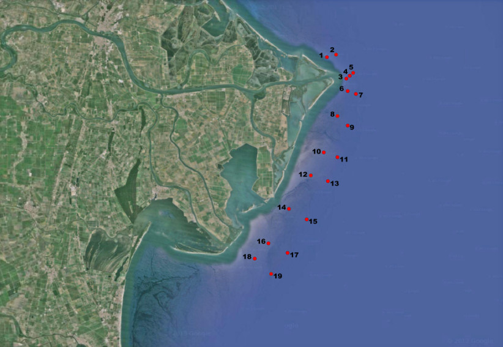

## lettura dei dati

```r
load("./dati/MateriaOrganica.Rdata")
str(dati)
```

```
## 'data.frame':    19 obs. of  2 variables:
##  $ Temperatura     : num  17.3 16.4 17.7 17 16.8 ...
##  $ Materia.Organica: num  13.2 16.7 13.1 13.5 13.9 ...
```

## Visualizzazione

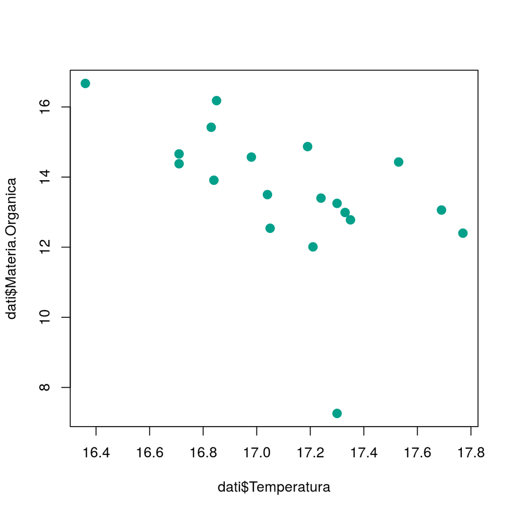

```r
plot(x=dati$Temperatura,y=dati$Materia.Organica,pch=20,col=2,cex=2)
```

# Misure di dipendenza e interpolazioni lineari

Chiameremo:  
$Y=Materia.Organica$ e  
$X=Temperatura$

Ad ogni osservazione di Temperatura (Materia.Organica) sottraiamo la sua media:  
$x_i-\bar{x}$ e $y_i-\bar{y}$

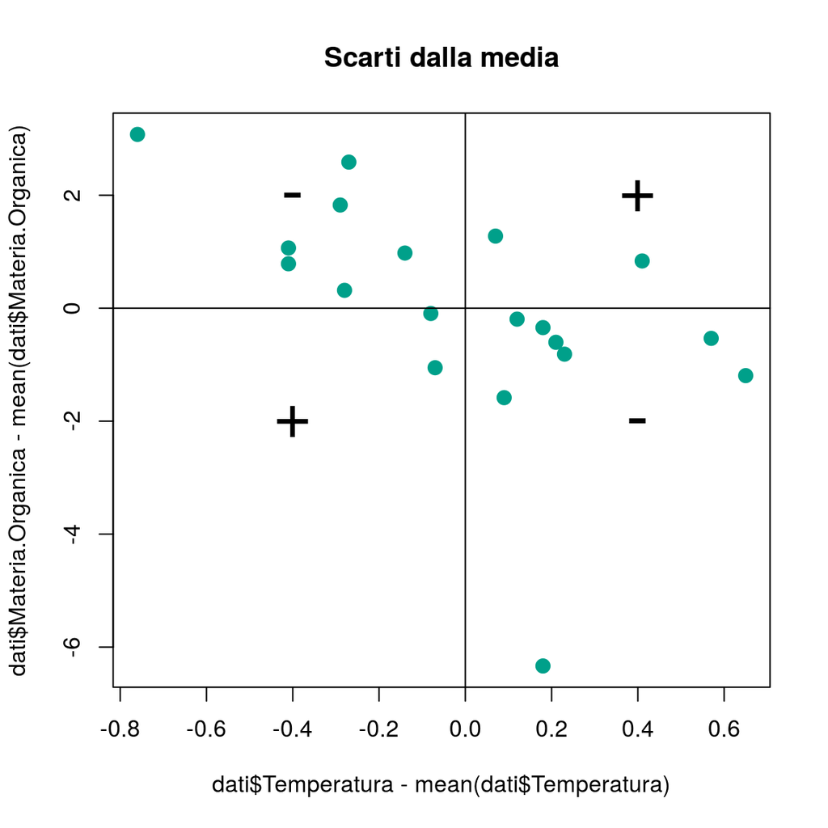

```r
plot(dati $Temperatura-mean(dati $Temperatura),
     dati $Materia.Organica-mean(dati $Materia.Organica),pch=20,col=2,cex=2)
title("Scarti dalla media")
abline(v=0)
abline(h=0)
text(.4,2,"+",col="black",cex=3)
text(-.4,-2,"+",col="black",cex=3)
text(-.4,2,"-",col="black",cex=3)
text(.4,-2,"-",col="black",cex=3)
```

## Covarianza e Varianza

**Covarianza** tra $X$ e $Y$: $\sigma_{xy} = \frac{\sum_{i=1}^n (x_i-\bar{x})(y_i-\bar{y})}{n}$

- varia tra $-\infty$ e $\infty$
- $\sigma_{xy}\approx 0$: non c’è dipendenza tra $X$ e $Y$
- $\sigma_{xy} >> (<<) 0$: c’è una forte dipendenza positiva (negativa) tra $X$ e $Y$

**Varianza** di $X$ (=covarianza tra $X$ e $X$): $\sigma_{xx} = \sigma_{x}^2 = \frac{\sum_{i=1}^n (x_i-\bar{x})^2}{n}$

**Deviazione Standard** di $X$: $\sigma_{xx} = \sqrt{\sigma_{xx}}=\sigma_{x}$

**(Co)Varianza campionaria**di $X$: $\sigma_{xy}^o = \frac{\sum_{i=1}^n (x_i-\bar{x})(y_i-\bar{y})}{n-1}$

(analogamente per la varianza e la deviazione standard)

## Correlazione

Con la Covarianza è difficile stabilire quando la relazione tra $X$ e $Y$ è forte/debole. Notiamo che (in realtà)

$-\sigma_{x}\sigma_{y}\leq \sigma_{xy}\leq \sigma_{x}\sigma_{y}$ divido i tre membri della disuguaglianza per $\sigma_x\sigma_y$:

$-1\leq \frac{\sigma_{xy}}{\sigma_{x}\sigma_{y}}\leq 1$

**Correlazione** tra $X$ e $Y$: $\rho_{xy} = \frac{\sigma{xy}}{\sigma_{x}\sigma_{y}}= \frac{\sum_{i=1}^n (x_i-\bar{x})(y_i-\bar{y})}{\sqrt{\sum_{i=1}^n (x_i-\bar{x})^2}\sqrt{\sum_{i=1}^n (y_i-\bar{y})^2}}$

- varia tra $-1$ e $1$  
  -$\rho_{xy} \approx 0$: non c’è dipendenza tra $X$ e $Y$  
  -$\rho_{xy} \approx 1(-1)$: c’è una forte dipendenza positiva (negativa) tra $X$ e $Y$

## Linea di Tendenza, metodo dei Minimi Quadrati

Descriviamo la relazione tra  
$Y=Materia.Organica$ e  
$X=Temperatura$ con una retta.

$Materia.Organica = \beta_0 + \beta_1 Temperatura$  
$Y=\beta_0+\beta_1X$

Facciamo passare una retta ‘in mezzo’ ai dati.

## Stimatori ai Minimi Quadrati

Cerchiamo quella che passa più ‘in mezzo’, quella che minimizza la somma dei quadrati dei residui:

$\hat{\beta}_0$ e $\hat{\beta}_1$ tali che $\sum_{i=1}^n(y_i-(\hat{\beta}_0+ \hat{\beta}_1x_i ))^2$ sia minimo

(il più piccolo in assoluto).

## Coefficienti $\hat{\beta}$ e $\hat{y}$ stimati

- Coefficiente angolare: $\hat{\beta}_1=\frac{\sigma{xy}}{\sigma_{xx}}=\frac{\sum_{i=1}^n(x_i-\bar{x})(y_i-\bar{y})}{\sum_{i=1}^n (x_i-\bar{x})^2}=−2.976$
- Intercetta: $\hat{\beta}_0= \bar{y} -\hat{\beta}_1\bar{x}=64.539$
- Risposta ($y$ stimata): $\hat{y}_i = \hat{\beta}_0+ \hat{\beta}_1x_i$
- Residui (dalla stima ai minimi quadrati):  
  $y_i-(\hat{\beta}_0+ \hat{\beta}_1 x_i) = y_i-\hat{y}_i$

e quindi i minimi quadrati sono la somma dei residui al quadrato:  
$\sum_{i=1}^n(y_i-\hat{\beta}_0+ \hat{\beta}_1x_i )^2=\sum_{i=1}^n(y_i-\hat{y}_i)^2$

## Stima e rappresentazione grafica

```r
model=lm(Materia.Organica~Temperatura,data=dati)
coefficients(model)
```

```
## (Intercept) Temperatura
##   64.538572   -2.975753
```

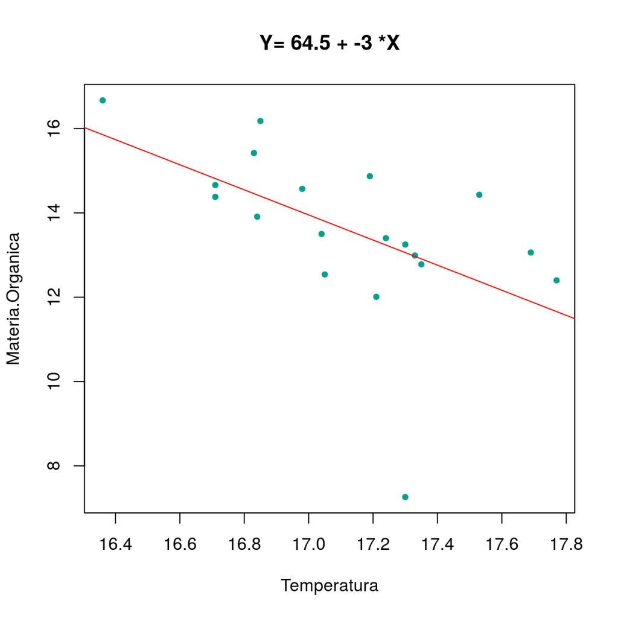

```r
plot(dati,pch=20,col=2,cex=1)
coeff=round(coefficients(model),1)
title(paste("Y=",coeff[1],"+",coeff[2],"*X"))
abline(model,col=1)
```

## Interpretazione dei coefficienti

- $\beta_0$ indica il valore di $y$ quando $x=0$  
  (dove la retta interseca l’asse delle ordinate).
- $\beta_1$ indica quanto cresce $y$ al crescere di una unità di $x$.
- Se $\beta_1=0$ non c’è relazione tra $x$ e $y$.$y$ è costante (orizzontale), conoscere $x$ non ci fa cambiare la stima di $y$
- Se $\beta_1>(<)0$ la relazione tra $x$ e $y$ è positiva (negativa). Quando $X$ passa da $x$ a $x+1$ la stima di $Y$ passa da $\hat{y}$ a $\hat{y}+\hat{\beta}_1$

## Decomposizione delle Varianza ed $R^2$

La **Devianza Totale** (Sum of Squares, SS): $DevTot=\sum_i^n (y_i - \bar{y})^2$

```r
(DevTot=sum((dati$Materia.Organica-mean(dati$Materia.Organica))^2))
```

```
## [1] 71.25964
```

può essere decomposta in  
**DevTot=DevResidua + DevSpiegata**$=\sum_i^n (y_i - \hat{y}_i)^2 +\sum_i^n (\hat{y}_i - \bar{y})^2$

$\hat{y}_i$: valori predetti dal modello $\hat{y}_i=\hat{\beta_0}+\hat{\beta_1}x_i$ In R, molto semplicemente:

```r
(predicted=predict(model))
```

```
##        1        2        3        4        5        6        7        8
## 13.05805 15.85526 11.89751 13.83174 14.42689 12.37363 14.01029 11.65944
##        9       10       11       12       13       14       15       16
## 12.90926 13.05805 13.32587 13.23659 14.39714 12.96878 14.45665 13.38538
##       17       18       19
## 14.81374 13.80199 14.81374
```

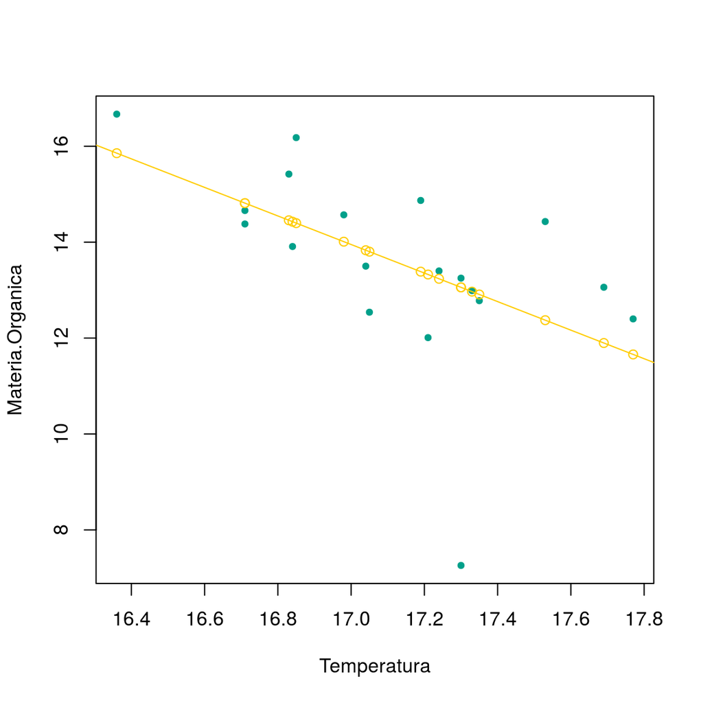

```r
plot(dati,pch=20,col=2,cex=1)
points(dati$Temperatura,predicted, col=3)
abline(model,col=3)
```

**Devianza Residua**: $DevResidua=\sum_i^n (y_i - \hat{y}_i)^2$

```r
(DevResidua= sum((dati$Materia.Organica - predicted)^2))
```

```
## [1] 51.0275
```

**Devianza Spiegata**: $DevSpiegata=\sum_i^n (\hat{y}_i - \bar{y})^2$

```r
(DevSpiegata= sum((predicted- mean(dati$Materia.Organica))^2))
```

```
## [1] 20.23214
```

Verifichiamo:

```r
(DevSpiegata+ DevResidua)
```

```
## [1] 71.25964
```

```r
DevTot
```

```
## [1] 71.25964
```

Allora posso mettere a rapporto la Devianza Spiegata con la Devianza Totale: **$R^2$**

```r
(R2=DevSpiegata/DevTot)
```

```
## [1] 0.2839215
```

e coincidenza strana (o no?):

```r
cor(dati$Temperatura,dati$Materia.Organica)^2
```

```
## [1] 0.2839215
```

# Verifica di Ipotesi (tramite Test di Permutazione)

**Esiste una relazione tra $Y$ e $X$**?

$\hat{\beta}_1= −2.9764$ ma il **vero valore** $\beta_1$ è davvero diverso da 0 (nessuna relazione)? O la stima ottenuta è diversa da 0 per effetto del caso?

- **Ipotesi Nulla** $H_0:\ \beta_1=0$ ($\beta_1$, non la sua stima $\hat{\beta}_1$!).  
  Non esiste alcuna relazione tra $X$ e $Y$.
- **Ipotesi Alternativa** $H_1:\ \beta_1<0$  
  La relazione è negativa (al crescere di $X$ cala $Y$).

Altre possibili specificazioni di $H_1:\ \beta_1>0$ e più comunemente $H_1:\ \beta_1\neq 0$.

## Distribuzione di $\hat{\beta}_1$ (Statistica Test) assumendo vera $H_0$

Supponiamo *vera l’ipotesi nulla $H_0$*.

Quali sono i possibili valori di $\beta_1$ condizionatamente ad $X$ e $Y$ osservati?

Sui dati osservati abbiamo calcolato:

```r
model=lm(Materia.Organica~Temperatura,data=dati)
#Beta_1 stimato:
coefficients(model)["Temperatura"]
```

```
## Temperatura
##   -2.975753
```

## I test di permutazione - in a nutshell -

Supponiamo in un esperimento:

```
##      X  Y
## [1,] 1 20
## [2,] 2 10
## [3,] 3 40
```

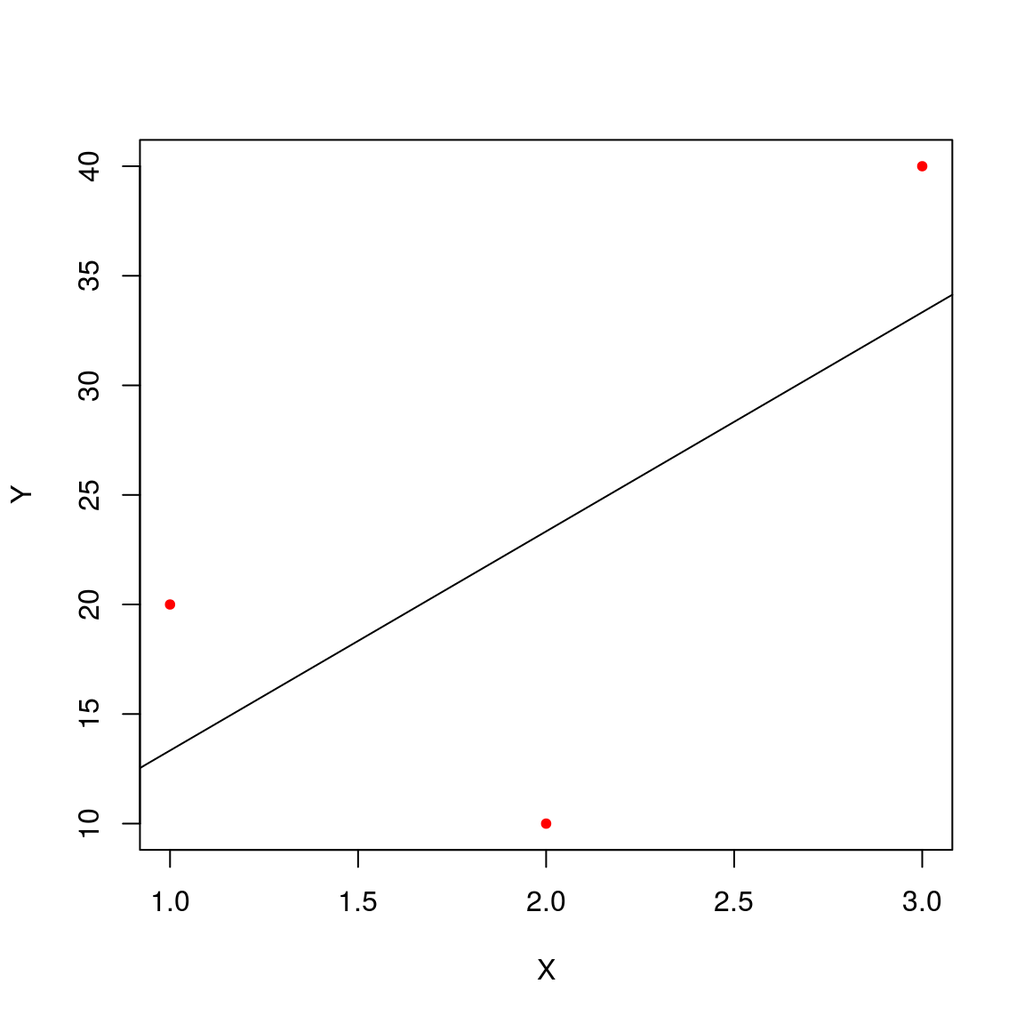

- *Se è vera $H_0$*: non c’è relazione lineare tra $X$ e $Y$
- Allora il trend che osservo potrebbe essere dovuto al caso.
- Ogni altra disposizione dei dati era ugualmente probabile
- Posso generare i dataset di altri ipotetici esperimenti scambiando l’ordine delle osservazioni in $Y$.
- Quanti dataset ugualmente verosimili potevo ottenere con $X$ e $Y$ osservati?  
  $3*2*1=3!=6$ possibili dataset.

## Tutti i potenziali dataset

```
##      X
## [1,] 1 20 10 10 40 40 20
## [2,] 2 10 20 40 10 20 40
## [3,] 3 40 40 20 20 10 10
```

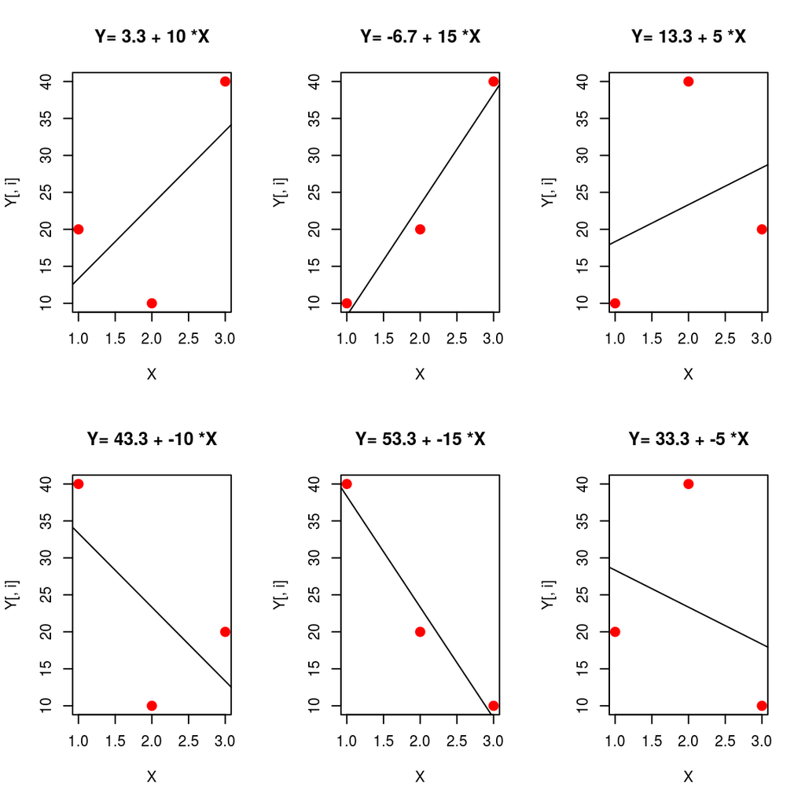

Applichiamo lo stesso principio ai nostri dati:

### Temperatura vs una permutazione di Materia Organica Totale

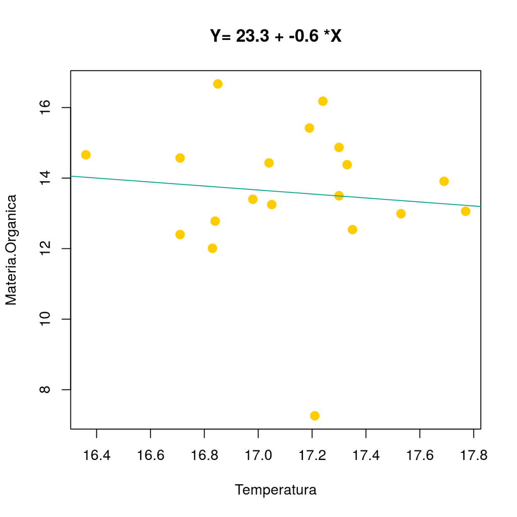

### Temperatura vs un’altra permutazione di Materia Organica Totale

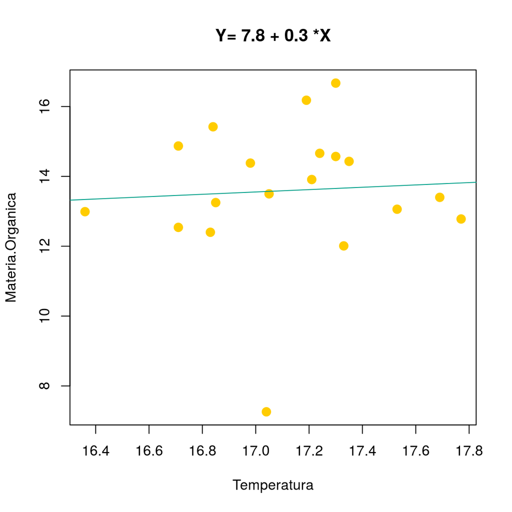

### Temperatura vs un’altra permutazione di Materia Organica Totale

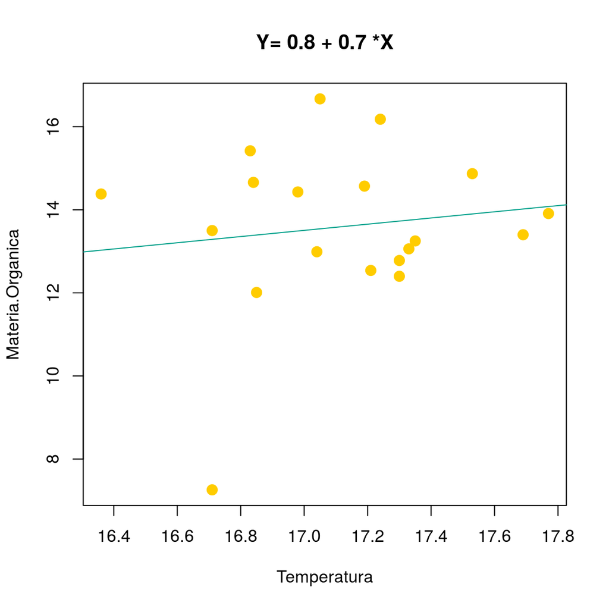

Ma quante sono le possibli permutazioni dei dati? $n!=1.216451E+17$.  
Decisamente troppo grande per noi. Ne calcoliamo un numero $B$ più piccolo (ma sufficientemente grande). Ad esempio:

### Replico 9999 e guardo l’istogramma dei $\hat{\beta}_1$

```r
B=10000
# beta_1 stimato sui dati osservati:
beta1=coefficients(lm(Materia.Organica~Temperatura,data=dati))[2]

# funzione che permuta i valori y e calcola il coeff beta_1
my.beta.perm <- function(Y,X){
  model=lm(sample(Y)~X)
  coefficients(model)[2]
}

#replico 9999 volte
beta.perm= replicate(B-1,my.beta.perm(datiPerm$Materia.Organica,
                      datiPerm$Temperatura ))

#il dataset osservato è una delle possibili permutazioni
beta.perm=c(beta1,beta.perm)
str(beta.perm)
```

```
##  Named num [1:10000] -2.976 1.166 -3.157 -1.143 -0.504 ...
##  - attr(*, "names")= chr [1:10000] "Temperatura" "X" "X" "X" ...
```

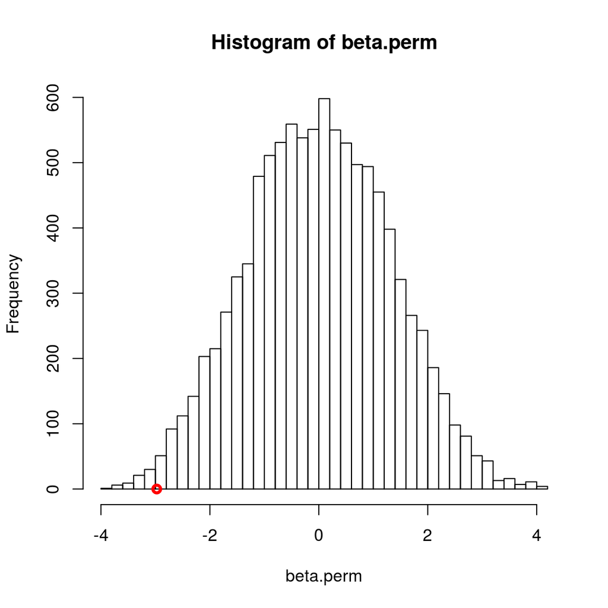

```r
hist(beta.perm,50)
points(beta1,0,lwd=3,col=1)
```

## Quanto probabile ERA $\hat{\beta}_1^{obs}$?

(prima dell’esperimento!) Quanto era probabile ottenere un valore $\leq\hat{\beta}_1^{obs}$ tra i tanti valori possibili di $\hat{\beta}_1^{*b}$ (ottenuti permutando i dati)?

Osservazioni:

- $\hat{\beta}_1^{*b} > \hat{\beta}_1^{obs}$ (valori più vicini allo 0) indicano MINORE evidenza verso $H_1$ di quanto non faccia $\hat{\beta}_1^{obs}$.
- $\hat{\beta}_1^{*b} \leq \hat{\beta}_1^{obs}$ indicano uguale o più evidenza verso $H_1$ di quanto non faccia $\hat{\beta}_1^{obs}$

## Calcolo del p-value

Su B=10^{4} permutazioni 72 volte: $\hat{\beta}_1^{*b} \leq \hat{\beta}_1^{obs}$.  
Il p-value (significatività) è $p=\frac{\#(\hat{\beta}_1^{*b} \leq \hat{\beta}_1^{obs})}{B+1}=$

```r
(p=sum(beta.perm<=beta1)/B)
```

```
## [1] 0.0072
```

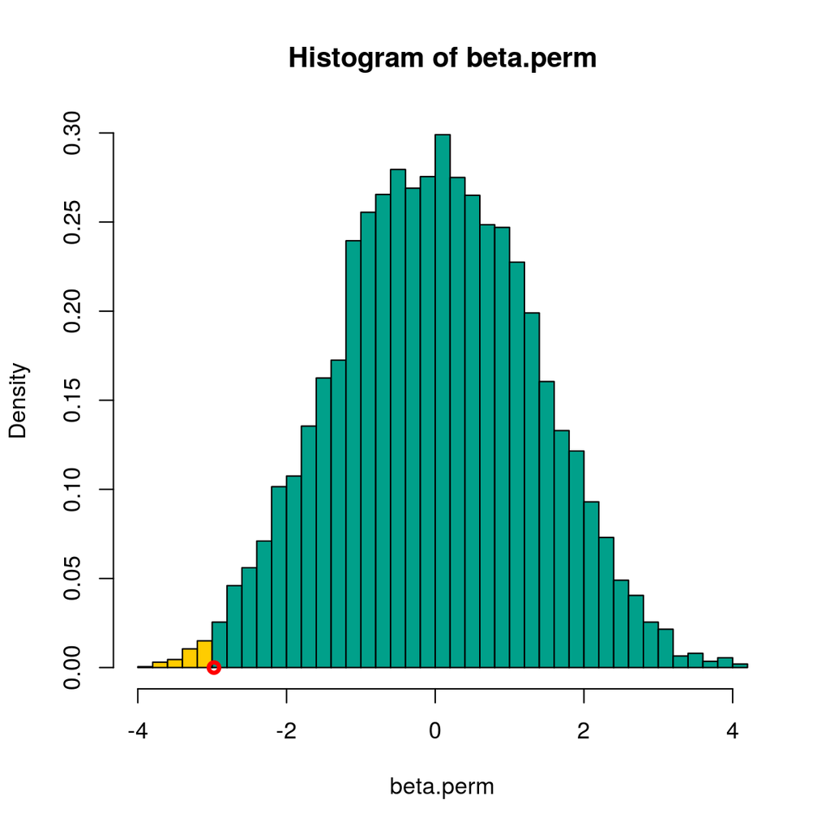

```r
hst=hist(beta.perm,plot=FALSE,50)
hist(beta.perm,col=(hst$breaks[-1]<=beta1)+2, probability=TRUE ,50)
points(beta1,0,lwd=3,col=1)
```

## Interpretazione

La probabilità di ottenere una stima $p=P(\hat{\beta}_1^*\leq\hat{\beta}_1=-2.9758|H_0)$ è pari a $p=$ 0.0072, cioè molto piccola. Quindi era poco probabile ottenere un valore come questo **SE è vera $H_0$**.

L’approccio di Neyman-Pearson ha reso comune l’uso di fissare una soglia di significatività ad esempio $\alpha=.05$ (o $=.01$). Quando $p\leq\alpha$ rifiuto l’ipotesi che non ci sia una relazione tra X e Y ($H_0$). Sono propenso a pensare che sia vera $H_1$ (esiste una relazione ed è negativa).

- Errore di I tipo: Falso Positivo  
  sono sotto $H_0$ (correlazione nulla) e decido di accettare $H_1$ (correlazione è negativa)
- Errore di II tipo: Falso Negativo  
  sono sotto $H_1$ (correlazione negativa) e non rifiuto $H_0$ (correlazione nulla)

### Innocente fino a prova contraria

**Controllo dell’errore di I tipo**

Vogliamo garantirci di non dire stupidaggini (pochi falsi positivi), meglio essere conservativi: $P(p-value \leq \alpha|H_0)\leq \alpha$

Cioè ho costruito una macchina che nel long run (molte repliche dell’esperimento) trova false correlazioni con probabilità $\alpha$ (es $0.05$, cioè 5%).

## Alternative composte (bilaterali)

L’ipotesi $H_1:\ \beta_1< 0$ (la relazione è negativa) deve essere giustificata con conoscenze a-priori.

Più frequentemente è opportuna l’ipotesi Alternativa:  
$H_1:\ \beta_1\neq 0$  
(esiste una relazione, non ipotizzo la direzione)

Considero anomali coefficienti stimati molto piccoli ma anche molto grandi (‘lontani da 0’). Il p-value è $p=\frac{\#(|\hat{\beta}_1^{*b} | \geq |\hat{\beta}_1^{obs}|)}{B+1} =$ 0.0172

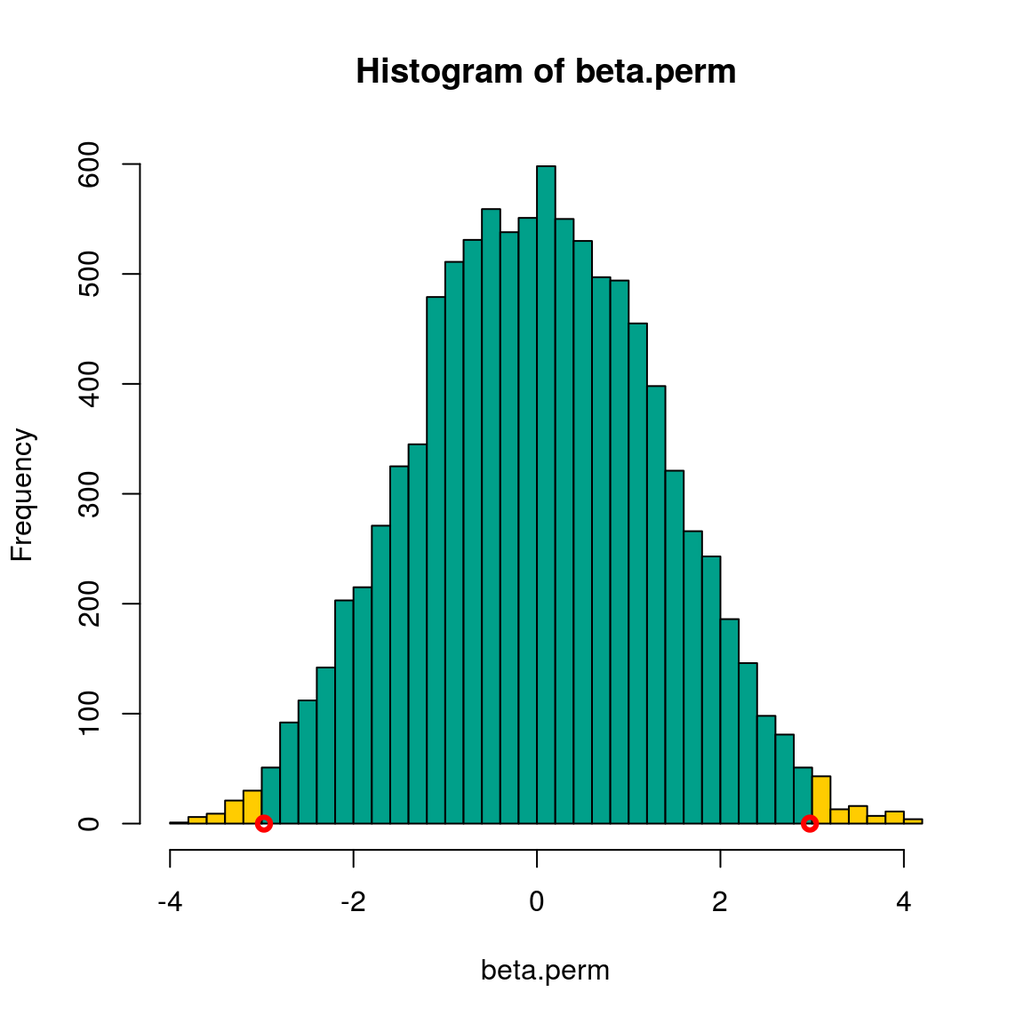

## I test di permutazione

- Non vanno confusi con i metodi bootstrap. I primi sono estrazioni senza reinserimento, i secondi con. I primi hanno proprietà quasi ottimali ed hanno (quasi sempre) un controllo esatto degli errori di primo tipo.
- Costituiscono un approccio generale e sono applicabili in molti contesti. Pochissime le assunzioni.
- Trovate alcune library R dedicate: [coin](http://cran.r-project.org/web/packages/coin/index.html) e [flip](http://cran.r-project.org/web/packages/flip/index.html) (la versione sviluppo è su [github](https://github.com/livioivil/flip) )
- Sono di applicabilità limitata quando ci sono molte variabili in gioco.

## Dai test di permutazione (non parametrici) ai test parametrici

Possiamo notare che l’istogramma delle statitiche test (calcolate sui dati permutati) è ben descritto da una curva **Gaussiana** (normale).

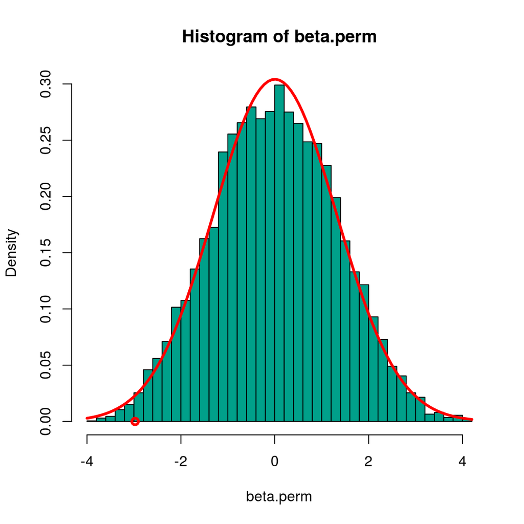

```r
hist(beta.perm,50,probability = TRUE,col=2)
curve(dnorm(x,mean(beta.perm),sd(beta.perm)),add=TRUE,col=1,lwd=3)
points(beta1,0,lwd=3,col=1)
```

Senza necessità di usare la strategia di permutazione dei dati, possiamo ottenere risulati analitici più ‘compatti’ e guadagnare ulteriori vantaggi (ad un certo prezzo).

## Il modello lineare (semplice)

Assumiamo che i valori osservati si distribuiscano attorno ai veri valori $\beta_0 + \beta_1 X$ secondo una legge gaussiana:

$Y = \textrm{parte lineare} + \textrm{errore normale}$

$Y = \beta_0 + \beta_1 X + \varepsilon$

**Assunzioni del modello lineare**

1. $\boldsymbol{y_i = \beta_0 + \beta_1 x_i + \varepsilon_i}$ la relazione tra X e Y è veramente lineare a meno del termine di errore $\varepsilon_i$
2. le **osservazioni** sono tra loro **indipendenti**  
   conoscere il valore dell’osservazione $y_i$ non mi aiuta a prevedere il valore di $y_{i+1}$
3. $\boldsymbol{\varepsilon_i \sim N(0,\sigma^2), \ \forall i=1,\ldots,n}$  
   gli errori hanno distribuzione normale con media nulla e stessa varianza (omoschedasticità: stessa varianza).

## Stima dei veri valori della popolazione

L’ipotesi che facciamo è che esista una vera coppia di valori $\beta_0,\beta_1$ nella popolazione delle possibili rilevazioni (nella realtà).

$\hat{\beta}_0=64.539$ e $\hat{\beta}_1= −2.976$ sono le stime che facciamo di questi veri valori $\beta_0$ e $\beta_1$ che sono ignoti e sono l’obiettivo della nostra indagine.

Lo stimatore ai *Minimi Quadrati* è un ‘buon’ metodo, garantisce di produrre valori il più vicino possibile ai veri valori.

## Verifica di Ipotesi

Se sono veri questi assunti,

$\hat{\beta_1}\sim N(\beta_1,\sigma^2/\sum(x_i-\bar{x})^2)$

Calcoliamo la statistica test:

$t=\frac{\hat{\beta_1}}{dev.std\ di\ \hat{\beta_1}}=\frac{\hat{\beta_1}}{\sqrt{\sum_{i=1}^n(y_i-\hat{y}_i)^2/\sum(x_i-\bar{x})^2/(n-2)}}$

Se è vera $H_0:\beta_1=0$, $t\sim t(n-2)$

Sui dati di Temperatura e $H_1: \beta_1\neq 0$ (alternativa bilaterale)

```r
model=lm(Materia.Organica~Temperatura,data=dati)
summary(model)
```

```
##
## Call:
## lm(formula = Materia.Organica ~ Temperatura, data = dati)
##
## Residuals:
##     Min      1Q  Median      3Q     Max
## -5.7980 -0.3827  0.1634  0.8890  2.0564
##
## Coefficients:
##             Estimate Std. Error t value Pr(>|t|)
## (Intercept)   64.539     19.627   3.288  0.00434 **
## Temperatura   -2.976      1.146  -2.596  0.01883 *
## ---
## Signif. codes:  0 '***' 0.001 '**' 0.01 '*' 0.05 '.' 0.1 ' ' 1
##
## Residual standard error: 1.733 on 17 degrees of freedom
## Multiple R-squared:  0.2839, Adjusted R-squared:  0.2418
## F-statistic:  6.74 on 1 and 17 DF,  p-value: 0.01883
```

### La potenza è nulla senza il controllo

Non sapremo mai con certezza se siamo sotto $H_0$ o sotto $H_1$. Ma abbiamo uno strumento che ci garantisce che se quando siamo sotto $H_0$ sputa fuori falsi rifiuti ($p\leq\alpha$) con probabilità $\alpha$.

Però anche un 1 su un dado a 20 è un evento che accade con probabilità $\alpha=5\%$. Perchè il p-value dei t-test è migliore?

Cosa possiamo dire del caso che siamo sotto $H_1$? commettiamo errori di II tipo (falsi negativi) con probabilità $P(p>\alpha)=\beta$ che ci è ignota, ma speriamo sia la più bassa possibile

Potenza: $1-\beta$, la probablità di trovare una relazione quando questa c’è veramente (sotto $H_1$).

Se sono rispettati gli assunti, i testi parametrici garantiscono - il controllo dell’errore di I tipo a livello $\alpha$, - la massima potenza (minimo errore di II tipo $\beta$) tra tutti i test possibili, - consistenza asintotica (se sono sotto $H_1$ rifiuto sempre per $n$ sufficientemente grandi).

I test di permutazione hanno solitamente potenza di poco minore e convergono ai corrispettivi test parametrici, se esistono.

## Intervalli di confidenza

L’approccio parametrico ci permette anche di calcolare intervalli di confidenza

```r
confint(model)
```

```
##                 2.5 %      97.5 %
## (Intercept) 23.129937 105.9472071
## Temperatura -5.393985  -0.5575202
```

Gli intervalli di confidenza sono costruiti in modo tale che nel long run includono il vero valore $\beta_1$ con probabilità $1-\alpha$ (es 95%). Una volta che i dati sono stati raccolti, non possiamo sapere se abbiamo incluso il vero valore $\beta_1$, possiamo solo sperare di esser caduti nel 95% buono dei casi..

Intervalli di confidenza e verifica di ipotesi sono strettamente legate: se un intervallo di confidenza a livello $1-\alpha$ non include lo 0, il p-value per la verifica di $H_0:\ \beta_1=0$ sarà $<\alpha$.

## Il modello Lineare Multiplo

Il modello lineare semplice è ‘facilmente’ estendibile al Modello Lineare Multiplo. Formalmente abbiamo gli stessi elementi, solamente prevediamo la combinazione lineare di più variabili.

$Y = \textrm{parte lineare} + \textrm{errore normale}$

$Y = \beta_0 + \beta_1 X_1 +\ldots+\beta_p x_p + \varepsilon$

Descriviamo così un (iper)piano di dimensione $p$

**Assunzioni del modello lineare multiplo** Sono le stesse del modello lineare semplice

1. $y_i = \beta_0 + \beta_1 x_{1i} +\ldots+\beta_p x_{pi} + \varepsilon_i$ la relazione tra X e Y è veramente lineare a meno del termine di errore $\varepsilon_i$
2. le **osservazioni** sono tra loro **indipendenti**
3. $\boldsymbol{\varepsilon_i \sim N(0,\sigma^2), \ \forall i=1,\ldots,n}$

(torneremo sul modello multiplo più avanti)

## Regressione lineare in R

> lm(formula,…)

dove:  
*formula* specifica il legame tra la dipendente e le indipendenti (o predittori)

## Esempi di specificazione del modello di regressione

Siano $y$ la variabile dipendente e $x$ e $z$ due predittori

| **Regressione** | **Regressione in R** |
| --- | --- |
| $y=\beta_{0}+\beta_{1}x$ | $lm(y \sim x)$ |
| $y=\beta_{0}+\beta_{1}x+\beta_{2}z$ | $lm(y \sim x+z)$ |
| $y=\beta_{0}+\beta_{1}x+\beta_{2}z+\beta_{3}xz$ | $lm(y \sim x+z+x:z)$ |
| $y=\beta_{0}+\beta_{1}x+\beta_{2}z+\beta_{3}xz$ | $lm(y \sim x * z)$ |

Per altre opzioni sulla specificazione di un modello in R vedi: > ?formula

## Passi fondamentali di un modello di regressione

| **Passo** | **Codice R** | **Librerie** |
| --- | --- | --- |
| Costruzione modello | $model=lm(formula)$ | stats |
| Verifica assunzioni | $plot(model)$ | stats |
| Valutazione parametri | $summary(model)$ | stats |
| Analisi della varianza | $anova(model)$ | stats |
| Analisi della varianza | $Anova(model,type=``III'')$ | car |
| Visualizzazione degli effetti | vedi $?effect$ | effects |
| Confronto con altri modelli* | $anova(model,model2)$ | stats |
| Confronto con altri modelli** | $AIC(model)$ ; $AIC(model2)$ | stats |

* confronto tra modelli *nested* basato sul test $F$  
** confronto tra modelli basato sull’Akaike Information Criterion (AIC) o sul Bayesian Information Criterion (BIC): vedi **?AIC**

## Torniamo al nostro esempio (modello lineare semplice)

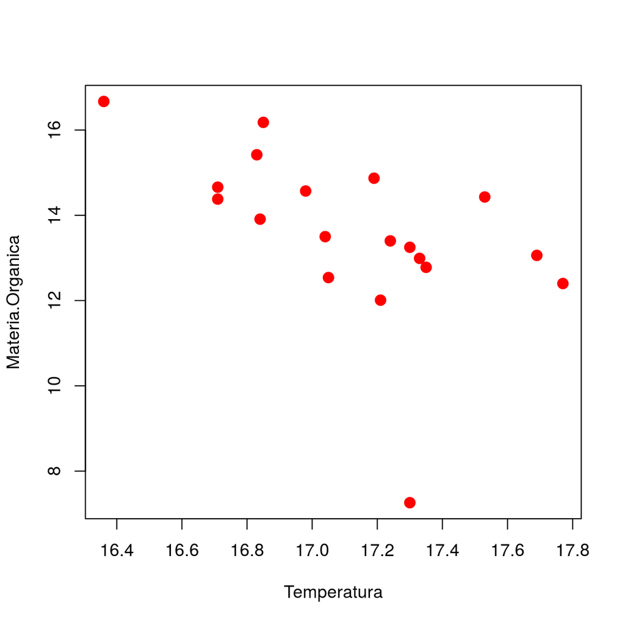

```
## integer(0)
```

```r
plot(dati,pch=20,col=1,cex=2)
# per identificare osservazioni sul grafico con il mouse
identify(dati$Temperatura,dati$Materia.Organica)
```

## Stima del modello e valutazione dei parametri

```r
model=lm(Materia.Organica~Temperatura,data=dati)
summary(model)
```

```
##
## Call:
## lm(formula = Materia.Organica ~ Temperatura, data = dati)
##
## Residuals:
##     Min      1Q  Median      3Q     Max
## -5.7980 -0.3827  0.1634  0.8890  2.0564
##
## Coefficients:
##             Estimate Std. Error t value Pr(>|t|)
## (Intercept)   64.539     19.627   3.288  0.00434 **
## Temperatura   -2.976      1.146  -2.596  0.01883 *
## ---
## Signif. codes:  0 '***' 0.001 '**' 0.01 '*' 0.05 '.' 0.1 ' ' 1
##
## Residual standard error: 1.733 on 17 degrees of freedom
## Multiple R-squared:  0.2839, Adjusted R-squared:  0.2418
## F-statistic:  6.74 on 1 and 17 DF,  p-value: 0.01883
```

(per ora) Si noti che il test $F$ ha la stessa significatività del test t.

## Rappresentazione grafica dell’effetto dell’Temperatura

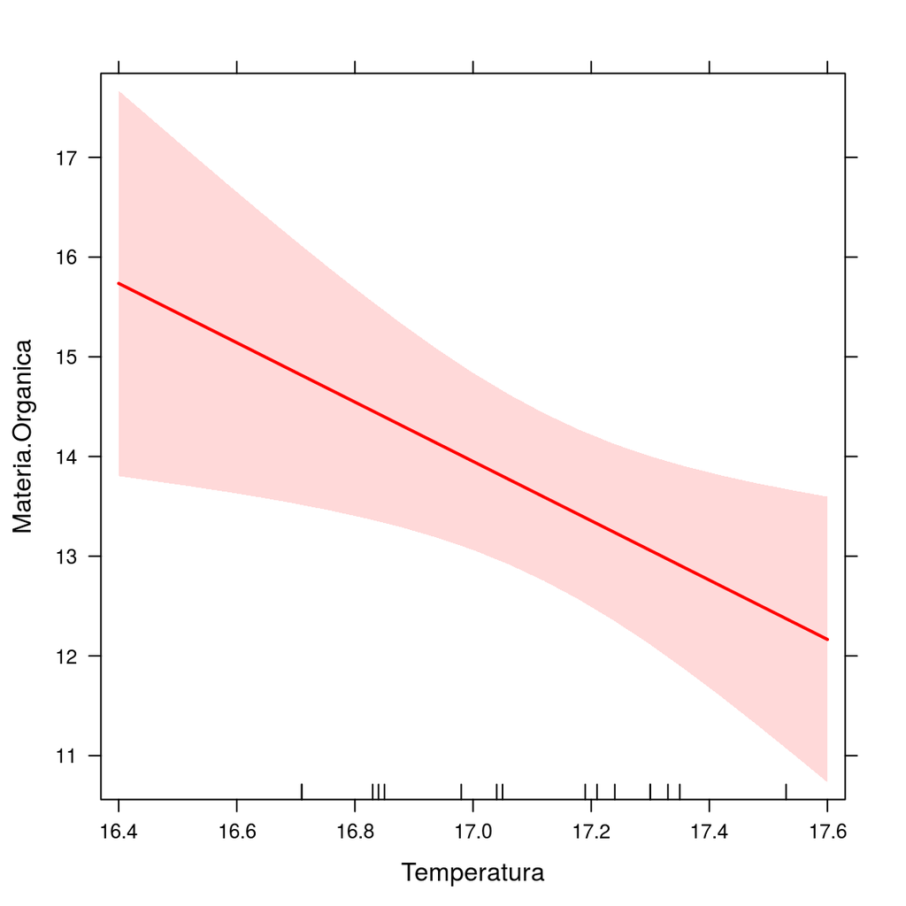

```r
library(effects) # vedi: ?effect
eff <- allEffects(model)
plot(eff,'Temperatura',ask=F,main='')
```

## Valutazione delle assunzioni sui residui del modello

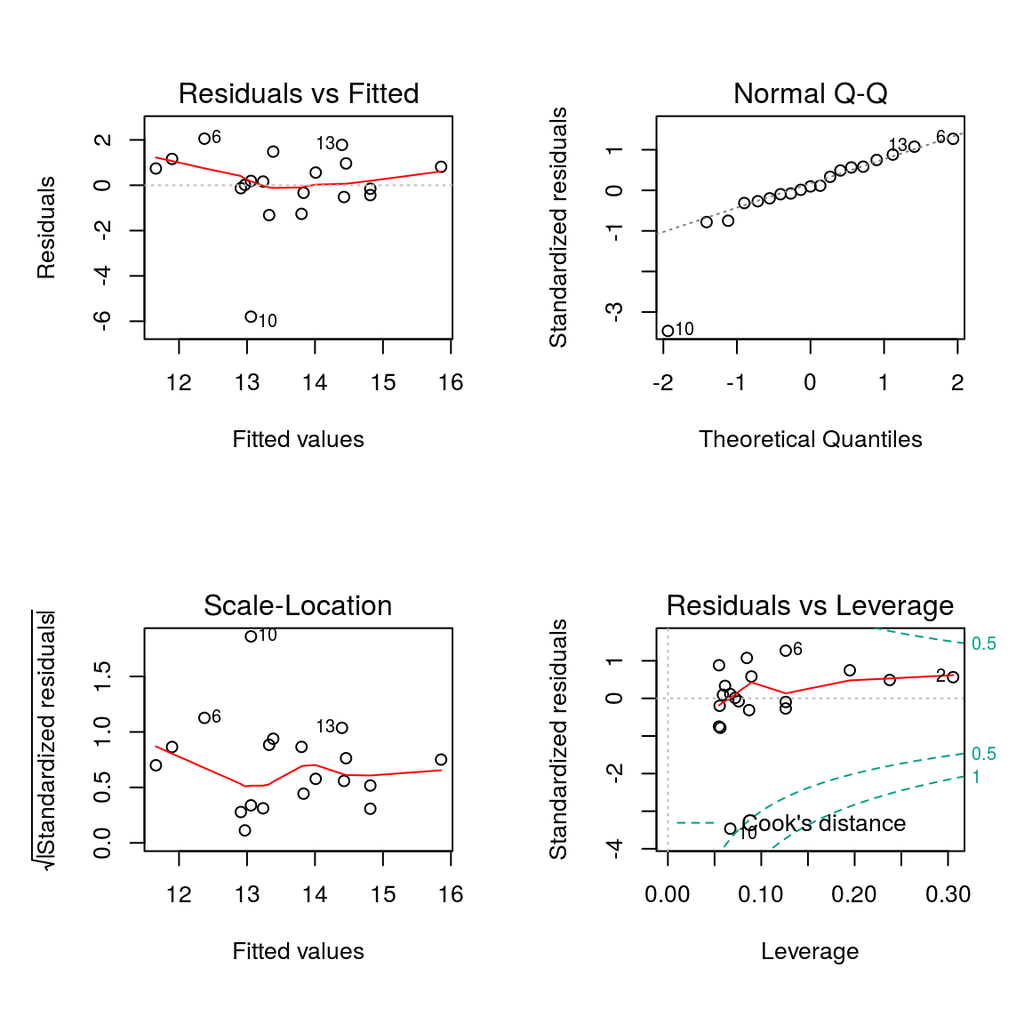

```r
par(mar=c(6, 5, 4, 2) + 0.1)
par(mfrow=c(2,2))
plot(model) # vedi anche: ?plot.lm per riferimenti bibliografici
```

- Indipendenza residui?
- Normalità residui?
- Omogeneità varianza residui?
- Presenza casi influenti?

Per favore, no test di normalità, di omoschedasticità etc. (controllano l’errore di primo tipo al contrario rispetto a quello che vorreste).

## Approfondimento: Alla ricerca di casi influenti

- In un modello statistico un *caso influente* è un’unità statistica le cui osservazioni hanno un forte impatto sulle stime dei parametri del modello
- Nei modelli di regressione , un modo particolarmente efficace per identificare valori influenti, è utilizzare *la distanza di Cook (Cook, 1977)*
- Data una unità statistica, la distanza di Cook è una misura di quanto cambierebbero i coefficienti di regressione del modello stimato se tale unità fosse omessa
- Maggiore è la distanza di Cook, tanto più l’unità statistica contribuisce a determinare i parametri del modello di regressione

## Identificazione di casi influenti

- Nel grafico appena visto R segnala le unità statistiche con valori di distanza di Cook prossimi a 0.5 e a 1, valori da considerare come soglie di attenzione.
- Fox, 2010, propone un cut-off per la distanza di Cook che tenga in considerazione il numero di osservazioni ($n$) e il numero di parametri ($k$) del modello: $\dfrac{4}{(n-k-1)}$

## Nel nostro caso…

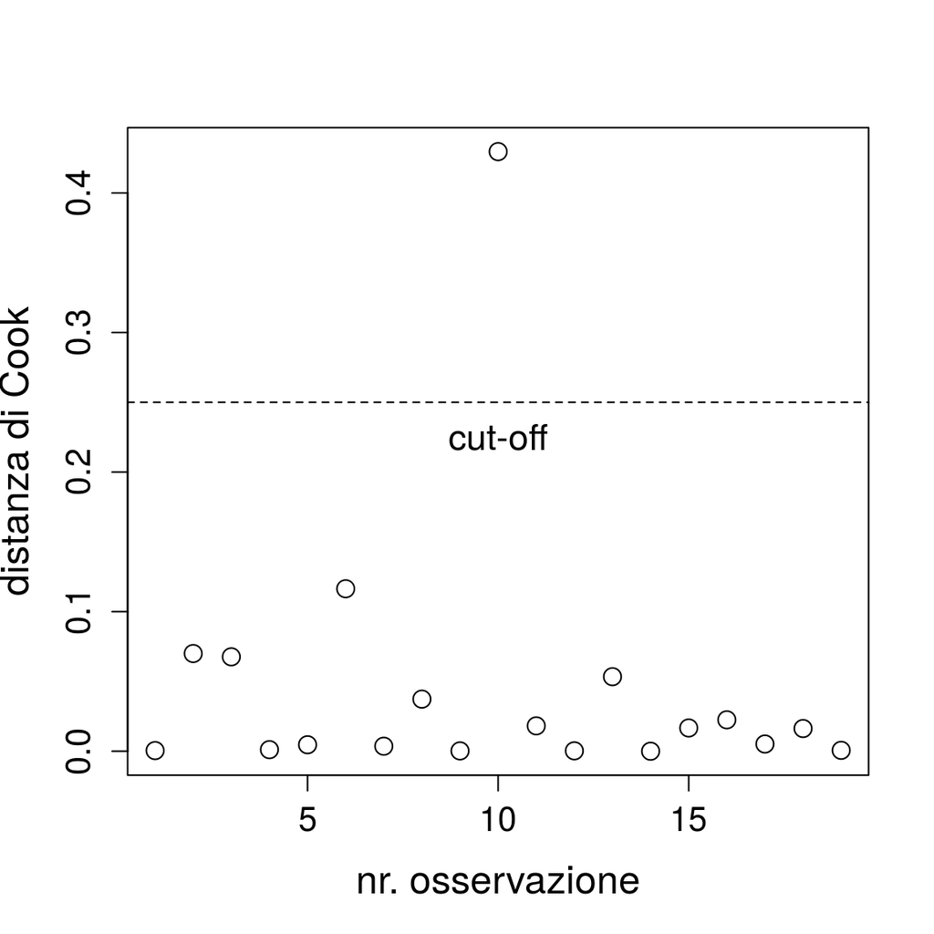

```r
# calcolo e rappresentazione della distanza di Cook
distanze.cook=cooks.distance(model)
plot(distanze.cook,xlab="nr. osservazione",ylab="distanza di Cook",cex=1.5,cex.axis=1.3,cex.lab=1.5)
# rappresentazione della linea di cutoff in corrispondenza del valore 4/(n-k-1)
n=nrow(dati) ; k=length(coefficients(model))
cutoff=4/(n-k-1)
abline(h=cutoff,lty=2)
text(10,cutoff*.9,"cut-off",cex=1.4)
```

## Nota Bene

- La distanza di Cook non è l’unico indicatore utile per valutare i casi influenti. Per una overview si veda in R: ?influence.measures
- L’identificazione, la valutazione e l’interpretazione dei casi influenti sono fasi fondamentali della modellazione statistica.
- Tuttavia questi aspetti sono spesso sottovalutati nelle applicazioni a casi concreti :-(

### **Esercizio 1.**

Costruire un modello di regressione eliminando l’osservazione 10. Cosa cambia?

## Esempio 2: Numero di scarpe e altezza dei biologi (marini)

```r
dati=read.csv("./dati/misureBiometricheStudenti.csv",sep=";",row.names=1)
```

$Y = {\beta}_{0}+ {\beta}_{1}X{1}+ \beta_{2}X_{2}+ \beta_{3}X_{1}X_{2}+ \epsilon$

dove:

- $Y$ = $h$, altezza
- $X_{1}$ = $n.scarpe$, numero di scarpe
- $X_{2}$ = $genere$

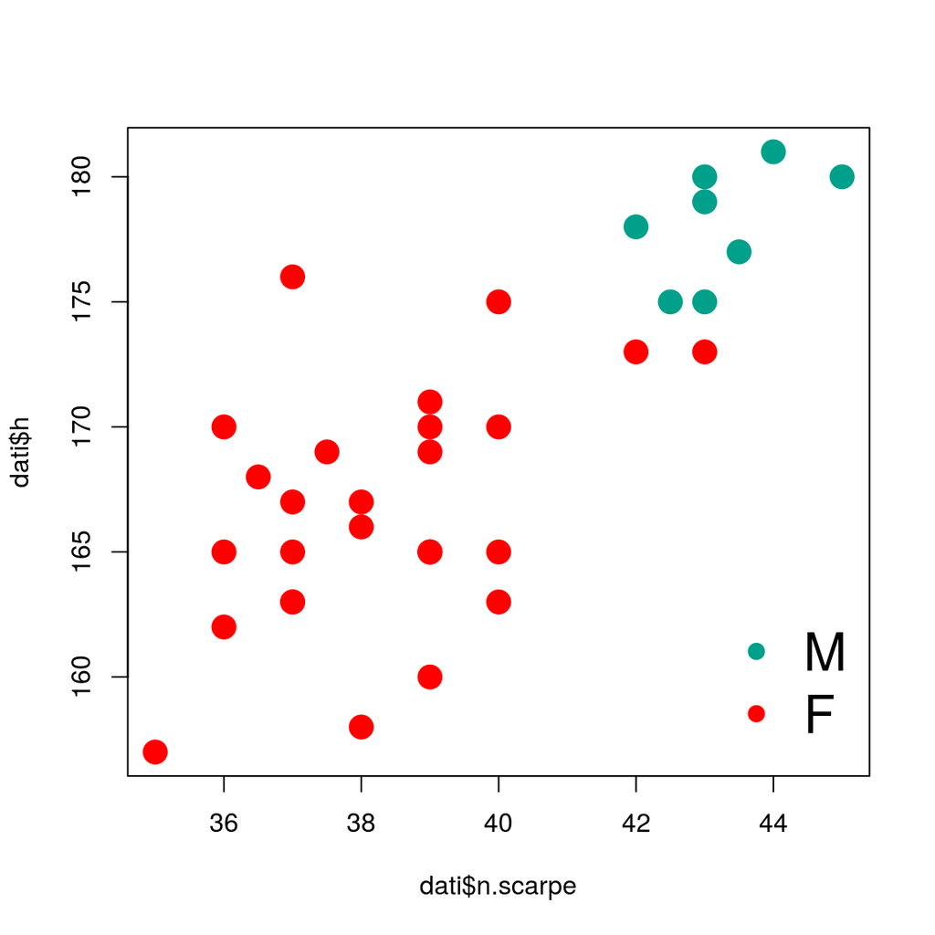

```r
plot(dati$n.scarpe, dati$h,col=(dati$genere=="M")+1,pch=20,cex=3)
legend("bottomright",legend=c("M","F"),pch=20,cex=2,col=c(2,1),bty="n")
```

Sappiamo stimare un modello lineare che preveda l’altezza $h$ attraverso il $n.scarpe$. **ESERCIZIO:** fatelo.

E’ possibile stimare un modello che usi $genere$ come predittore? come?

```r
modelGenere=lm(h~genere,data=dati)
summary(modelGenere)
```

```
##
## Call:
## lm(formula = h ~ genere, data = dati)
##
## Residuals:
##    Min     1Q Median     3Q    Max
## -9.667 -2.396 -0.125  2.604  9.333
##
## Coefficients:
##             Estimate Std. Error t value Pr(>|t|)
## (Intercept) 166.6667     0.8415  198.07  < 2e-16 ***
## genereM      11.4583     1.7600    6.51 2.17e-07 ***
## ---
## Signif. codes:  0 '***' 0.001 '**' 0.01 '*' 0.05 '.' 0.1 ' ' 1
##
## Residual standard error: 4.372 on 33 degrees of freedom
## Multiple R-squared:  0.5622, Adjusted R-squared:  0.549
## F-statistic: 42.38 on 1 and 33 DF,  p-value: 2.166e-07
```

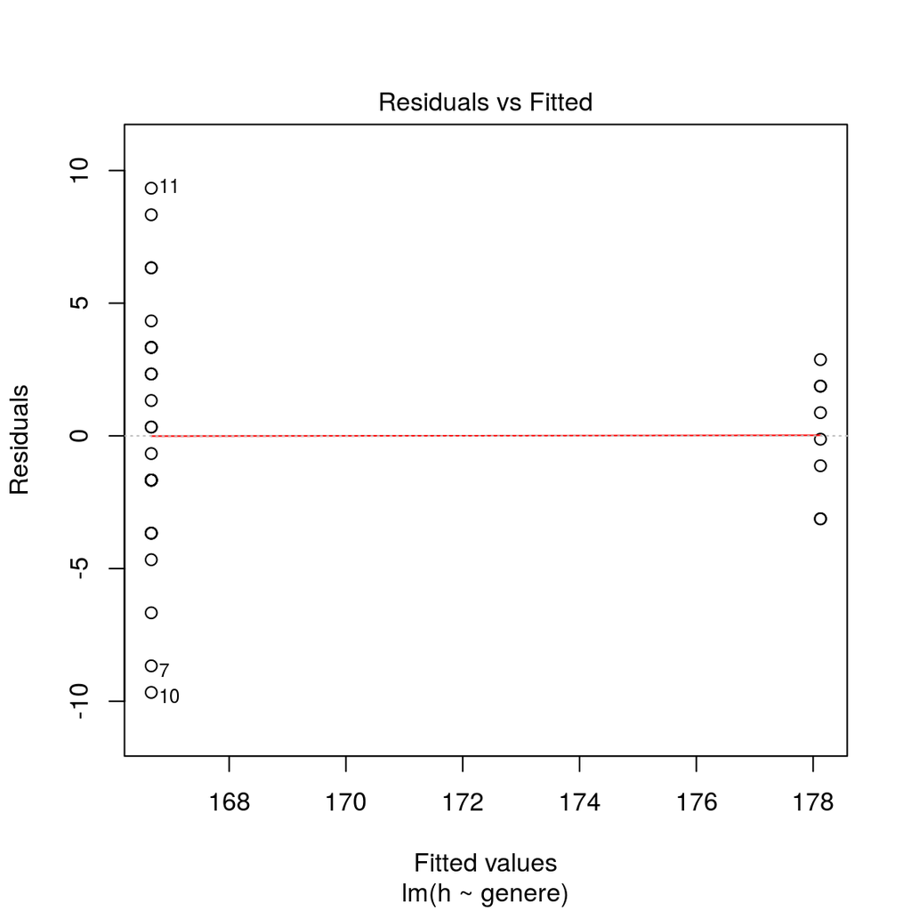

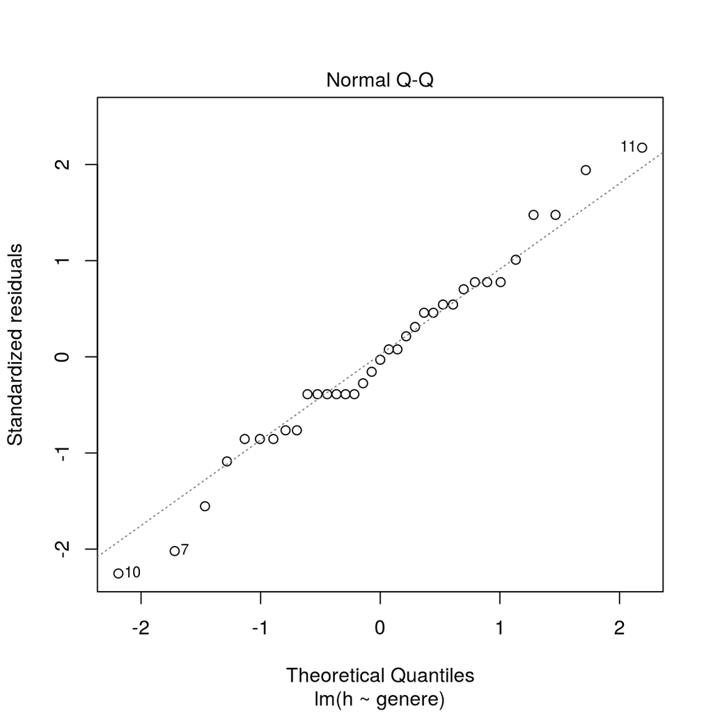

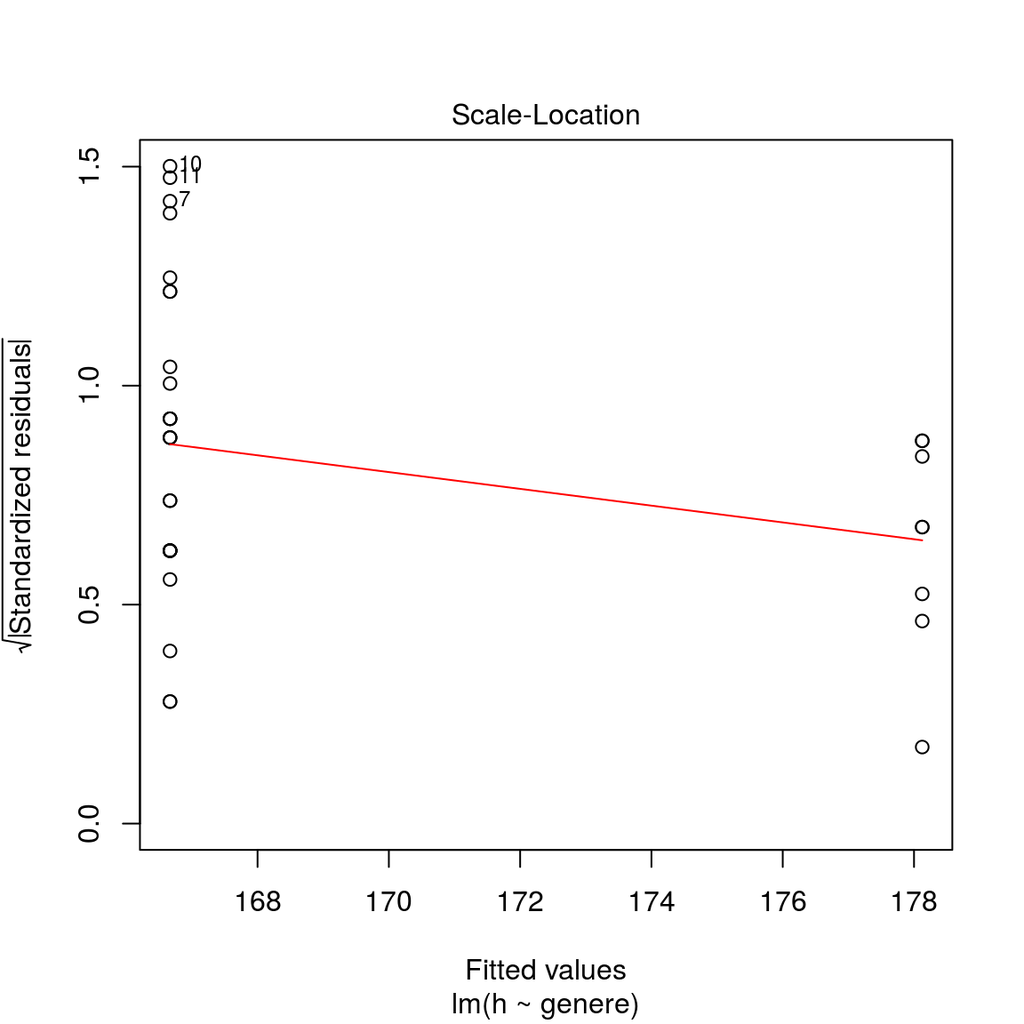

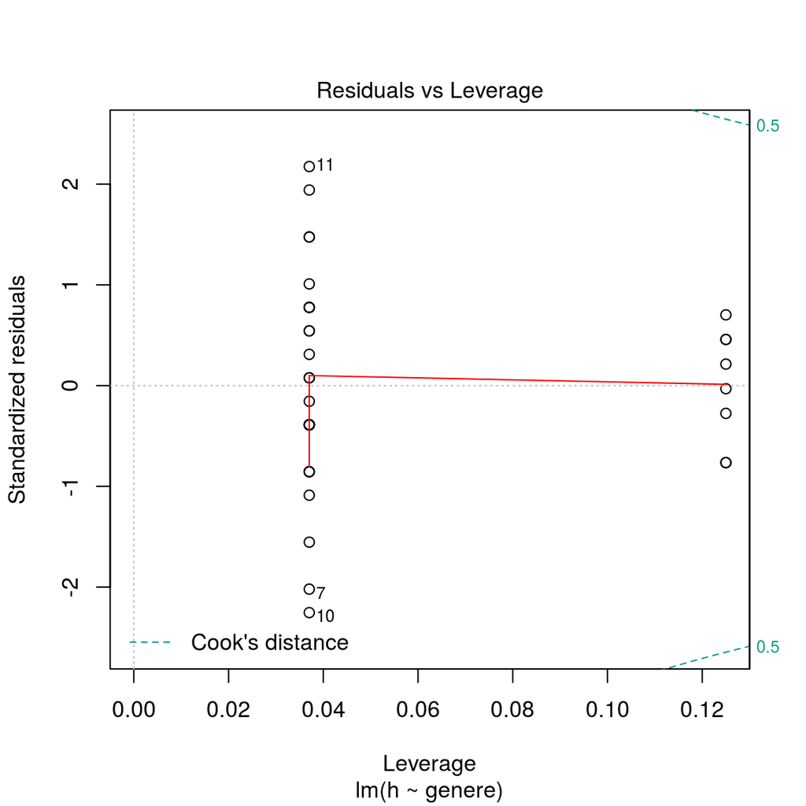

```r
plot(modelGenere)
```

. Come interpretiamo i coefficienti? . Che razza di modello stiamo stimando? . Quali le differenze con il mio vecchio amico t-test per due campioni indipendenti??

```r
by(dati$h,dati$genere,mean)
```

```
## dati$genere: F
## [1] 166.6667
## --------------------------------------------------------
## dati$genere: M
## [1] 178.125
```

```r
t.test(h~genere,data=dati,var.equal = TRUE)
```

```
##
##  Two Sample t-test
##
## data:  h by genere
## t = -6.5103, df = 33, p-value = 2.166e-07
## alternative hypothesis: true difference in means is not equal to 0
## 95 percent confidence interval:
##  -15.039156  -7.877511
## sample estimates:
## mean in group F mean in group M
##        166.6667        178.1250
```

## Modello lineare multiplo

Come stimare un modello che consideri $n.scarpe$, $genere$ e loro interazione?

```r
modelFull=lm(h~n.scarpe+genere+n.scarpe:genere,data=dati)
```

**Come interpretiamo il modello?**

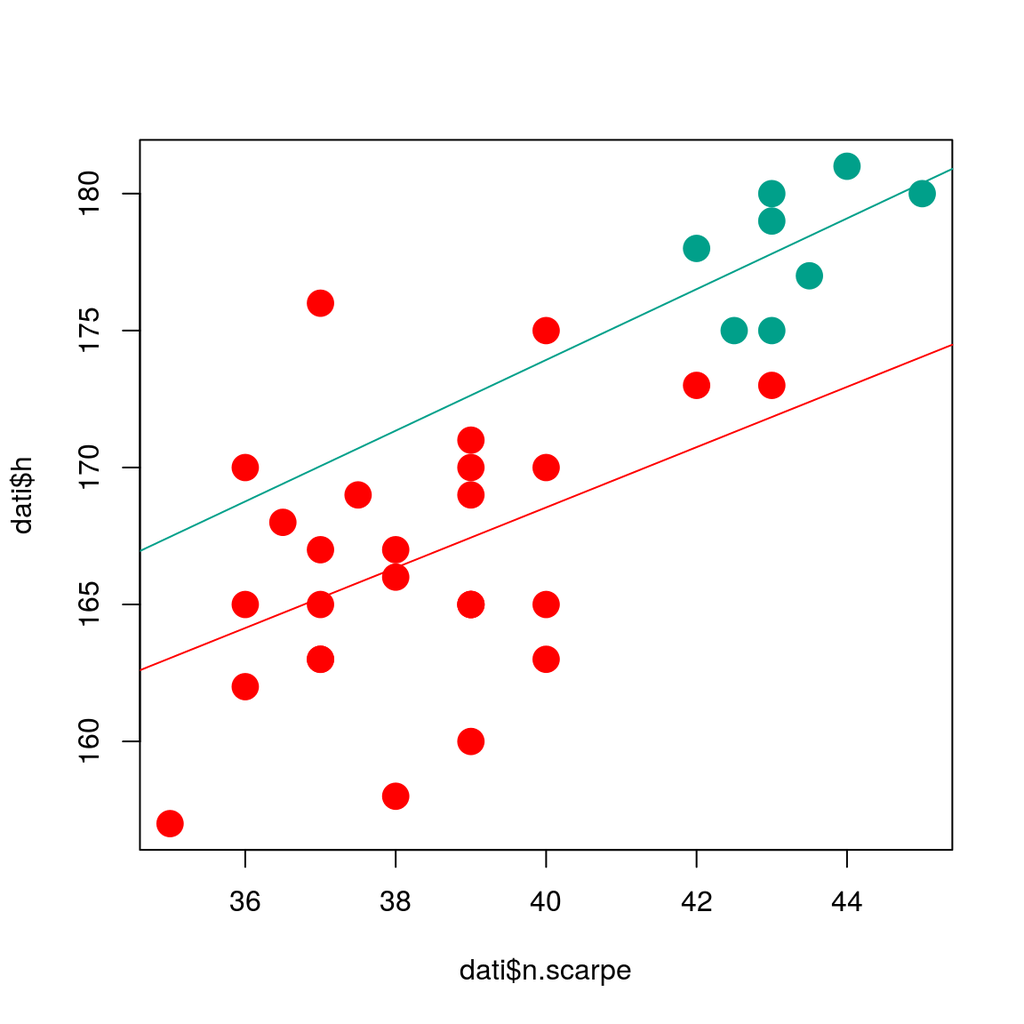

```r
plot(dati$n.scarpe, dati$h,col=(dati$genere=="M")+1,pch=20,cex=3)
abline(coefficients(modelFull)[1],coefficients(modelFull)[2],col=1)
abline(coefficients(modelFull)[1]+coefficients(modelFull)[3],coefficients(modelFull)[2]+coefficients(modelFull)[4],col=2)
```

**Come interpretiamo i risultati dell’analisi?**

```r
summary(modelFull)
```

```
##
## Call:
## lm(formula = h ~ n.scarpe + genere + n.scarpe:genere, data = dati)
##
## Residuals:
##     Min      1Q  Median      3Q     Max
## -8.3407 -2.3407  0.6593  2.0521 10.7596
##
## Coefficients:
##                  Estimate Std. Error t value Pr(>|t|)
## (Intercept)      124.5305    16.4084   7.589 1.48e-08 ***
## n.scarpe           1.1003     0.4280   2.571   0.0152 *
## genereM           -2.2701    73.6064  -0.031   0.9756
## n.scarpe:genereM   0.1914     1.7130   0.112   0.9118
## ---
## Signif. codes:  0 '***' 0.001 '**' 0.01 '*' 0.05 '.' 0.1 ' ' 1
##
## Residual standard error: 4.063 on 31 degrees of freedom
## Multiple R-squared:  0.6449, Adjusted R-squared:  0.6105
## F-statistic: 18.77 on 3 and 31 DF,  p-value: 3.983e-07
```

Il test $F$ (riportato in basso nella tabella) verifica l’ipotesi Nulla:  
$H_0:\ \beta_1=\ldots=\beta_p=0$ (tutti uguali a 0)  
contro  
$H_0:\$ Almeno un $\beta_i\neq 0$ (almeno uno diverso da 0)

In questo caso abbiamo ragione di credere che ci sia almeno un predittore utile tra genere, n.scarpe e loro interazione ($p<.05$).

I coefficienti sono stimati e testati al netto dell’effetto delle altre variabili…

### Correlazione tra predittori

Nei modelli di regressione multipla perdiamo la relazione tra correlazione ed $R^2$ (tra l’altro ci sono $p$ correlazioni possibili con $Y$).

La stima dei coefficienti è fatta in maniera congiunta, risente perciò della correlazione tra i predittori X

```r
cor(dati$n.scarpe,dati$genere=="M")
```

```
## [1] 0.7821186
```

è molto alta, questo porterà instabilità (maggiore varianza) nelle stime che saranno meno precise ( e quindi p-value più alti, intervalli di confidenza più ampi).

Questo è il principale motivo per cui utile avere esperimenti con piani fattoriali ortogonali (non discusso oggi)

### Analisi dei residui

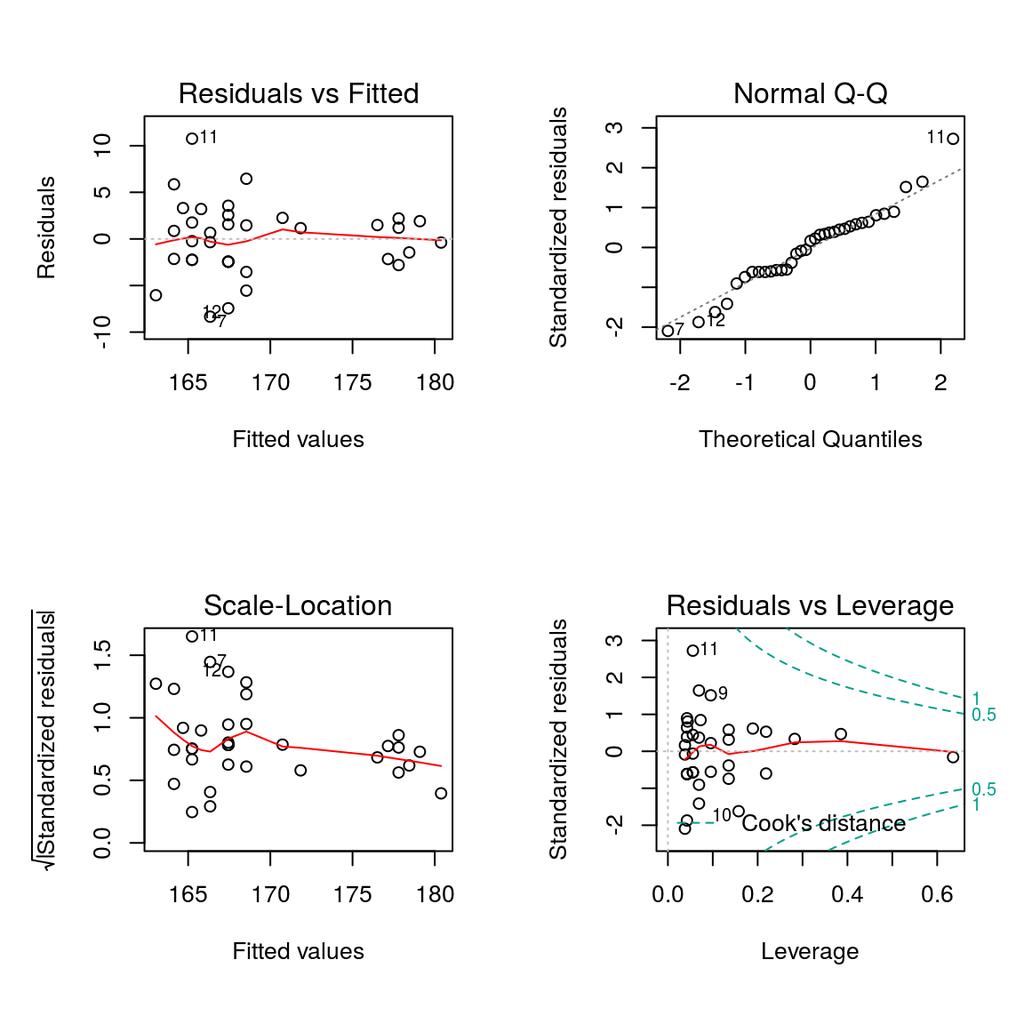

```r
par(mar=c(6, 5, 4, 2) + 0.1)
par(mfrow=c(2,2))
plot(modelFull) # vedi anche: ?plot.lm per riferimenti bibliografici
```

## Selezione di un buon modello

### Analisi della varianza (test per modelli annidati)

La Devianza Spiegata ed (ed $R^2$) aumenta - non diminuisce - ad ogni aggiunta di variabili  
(+ varibili = + flessibilità = better fit).  
ad esempio:

```r
summary(modelFull)
```

```
##
## Call:
## lm(formula = h ~ n.scarpe + genere + n.scarpe:genere, data = dati)
##
## Residuals:
##     Min      1Q  Median      3Q     Max
## -8.3407 -2.3407  0.6593  2.0521 10.7596
##
## Coefficients:
##                  Estimate Std. Error t value Pr(>|t|)
## (Intercept)      124.5305    16.4084   7.589 1.48e-08 ***
## n.scarpe           1.1003     0.4280   2.571   0.0152 *
## genereM           -2.2701    73.6064  -0.031   0.9756
## n.scarpe:genereM   0.1914     1.7130   0.112   0.9118
## ---
## Signif. codes:  0 '***' 0.001 '**' 0.01 '*' 0.05 '.' 0.1 ' ' 1
##
## Residual standard error: 4.063 on 31 degrees of freedom
## Multiple R-squared:  0.6449, Adjusted R-squared:  0.6105
## F-statistic: 18.77 on 3 and 31 DF,  p-value: 3.983e-07
```

```r
modelScaGen=lm(h~n.scarpe+genere,data=dati)
summary(modelScaGen)
```

```
##
## Call:
## lm(formula = h ~ n.scarpe + genere, data = dati)
##
## Residuals:
##     Min      1Q  Median      3Q     Max
## -8.3371 -2.3701  0.6629  2.0969 10.7751
##
## Coefficients:
##             Estimate Std. Error t value Pr(>|t|)
## (Intercept)  124.073     15.642   7.932 4.72e-09 ***
## n.scarpe       1.112      0.408   2.726   0.0103 *
## genereM        5.949      2.584   2.302   0.0280 *
## ---
## Signif. codes:  0 '***' 0.001 '**' 0.01 '*' 0.05 '.' 0.1 ' ' 1
##
## Residual standard error: 4 on 32 degrees of freedom
## Multiple R-squared:  0.6448, Adjusted R-squared:  0.6226
## F-statistic: 29.04 on 2 and 32 DF,  p-value: 6.434e-08
```

```r
modelScarpe=lm(h~n.scarpe,data=dati)
summary(modelScarpe)
```

```
##
## Call:
## lm(formula = h ~ n.scarpe, data = dati)
##
## Residuals:
##     Min      1Q  Median      3Q     Max
## -8.6474 -2.3410  0.1952  2.8122 11.1994
##
## Coefficients:
##             Estimate Std. Error t value Pr(>|t|)
## (Intercept)  96.4691    10.6805   9.032 1.94e-10 ***
## n.scarpe      1.8468     0.2703   6.833 8.49e-08 ***
## ---
## Signif. codes:  0 '***' 0.001 '**' 0.01 '*' 0.05 '.' 0.1 ' ' 1
##
## Residual standard error: 4.252 on 33 degrees of freedom
## Multiple R-squared:  0.5859, Adjusted R-squared:  0.5734
## F-statistic: 46.69 on 1 and 33 DF,  p-value: 8.494e-08
```

Dall’analisi sembra che l’interazione e il genere non siano predittivi.  
Testiamo questa ipotesi attraverso un confronto tra modelli nested

```r
anova(modelScaGen,modelFull)
```

```
## Analysis of Variance Table
##
## Model 1: h ~ n.scarpe + genere
## Model 2: h ~ n.scarpe + genere + n.scarpe:genere
##   Res.Df    RSS Df Sum of Sq      F Pr(>F)
## 1     32 511.96
## 2     31 511.75  1   0.20608 0.0125 0.9118
```

Tra i modelli multipli con o senza interazione non c’è differenza significativa in termini di varianza spiegata.

Escludere invece la variabile $genere$ invece non pare una buona idea:

```r
anova(modelScarpe,modelScaGen)
```

```
## Analysis of Variance Table
##
## Model 1: h ~ n.scarpe
## Model 2: h ~ n.scarpe + genere
##   Res.Df    RSS Df Sum of Sq      F  Pr(>F)
## 1     33 596.76
## 2     32 511.96  1      84.8 5.3004 0.02798 *
## ---
## Signif. codes:  0 '***' 0.001 '**' 0.01 '*' 0.05 '.' 0.1 ' ' 1
```

E neppure togliere $n.scarpe$:

```r
anova(modelGenere,modelScaGen)
```

```
## Analysis of Variance Table
##
## Model 1: h ~ genere
## Model 2: h ~ n.scarpe + genere
##   Res.Df    RSS Df Sum of Sq      F Pr(>F)
## 1     33 630.88
## 2     32 511.96  1    118.91 7.4327 0.0103 *
## ---
## Signif. codes:  0 '***' 0.001 '**' 0.01 '*' 0.05 '.' 0.1 ' ' 1
```

Il modello migliore (più parsimonioso) è quello con il solo $n.scarpe$ e $genere$ ma senza interazione.

## Selezione tra modelli tramite AIC e BIC

Si tratta di metodi che penalizzano i modelli con molti predittori.

Confrontiamo i BIC (Bayesian Information Criterion) o gli AIC (Akaike Information Criterion) dei modelli. L’idea: minore è il BIC e migliore è il modello

```r
n=nrow(dati)
( BIC1=AIC(modelFull,k=log(n)) )
```

```
## [1] 210.9898
```

```r
( BIC2=AIC(modelScaGen,k=log(n)) )
```

```
## [1] 207.4486
```

```r
( BIC3=AIC(modelScarpe,k=log(n)) )
```

```
## [1] 209.2576
```

```r
( BICGenere=AIC(modelGenere,k=log(n)) )
```

```
## [1] 211.2033
```

Il modello con n.scarpe + genere sembra essere il migliore.

```r
summary(modelScaGen)
```

```
##
## Call:
## lm(formula = h ~ n.scarpe + genere, data = dati)
##
## Residuals:
##     Min      1Q  Median      3Q     Max
## -8.3371 -2.3701  0.6629  2.0969 10.7751
##
## Coefficients:
##             Estimate Std. Error t value Pr(>|t|)
## (Intercept)  124.073     15.642   7.932 4.72e-09 ***
## n.scarpe       1.112      0.408   2.726   0.0103 *
## genereM        5.949      2.584   2.302   0.0280 *
## ---
## Signif. codes:  0 '***' 0.001 '**' 0.01 '*' 0.05 '.' 0.1 ' ' 1
##
## Residual standard error: 4 on 32 degrees of freedom
## Multiple R-squared:  0.6448, Adjusted R-squared:  0.6226
## F-statistic: 29.04 on 2 and 32 DF,  p-value: 6.434e-08
```

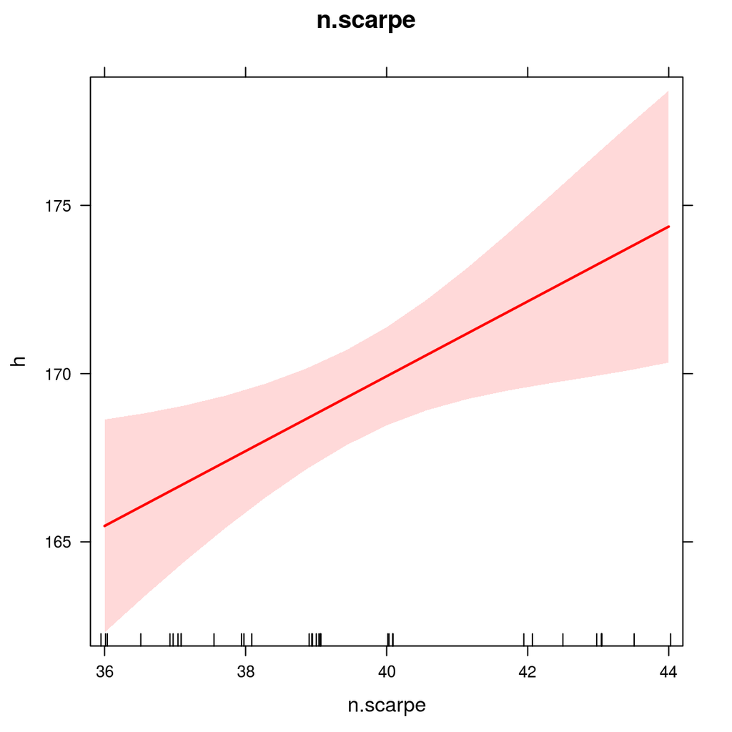

```r
eff <- allEffects(modelScaGen)
par(mfrow=c(1,2))
plot(eff,'n.scarpe',ask=F,main='n.scarpe')
```

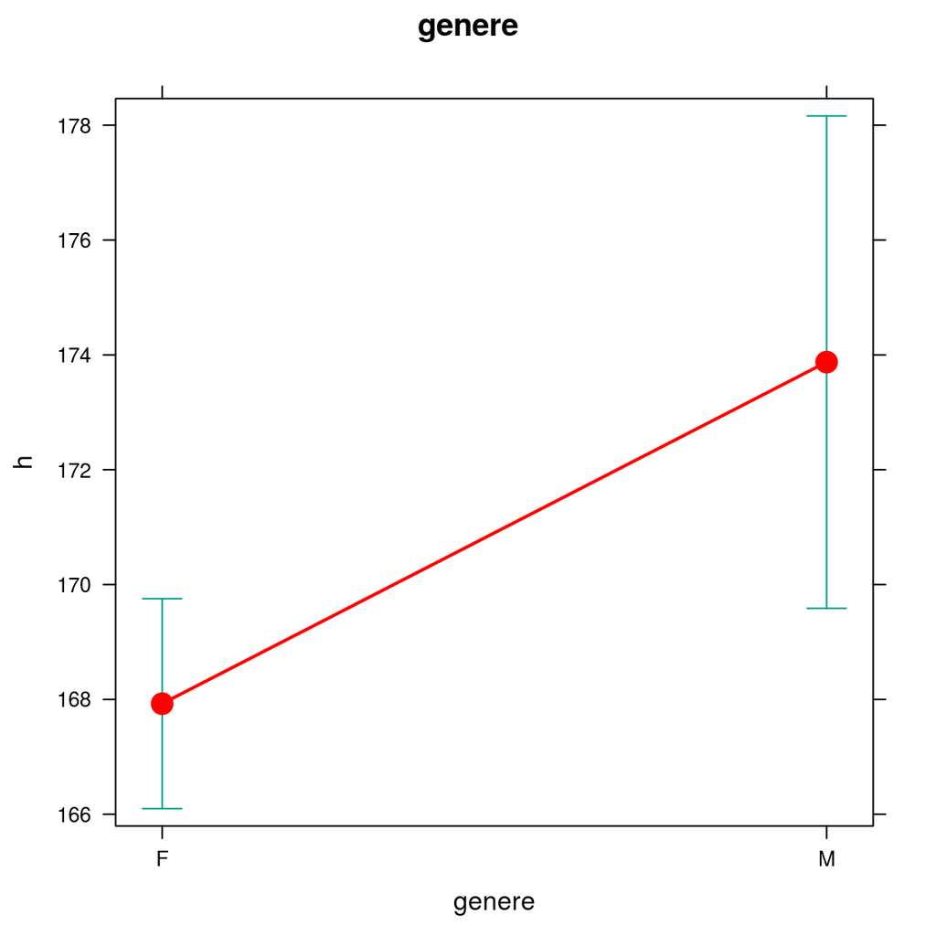

```r
plot(eff,'genere',ask=F,main='genere')
```

```r
par(mfrow=c(1,1))
```

**Approfondimento:** per la selezione del miglior modello in ottica bayesiana vedi anche ?step

Un riferimento utile: Wagenmakers (2006). A practical solution to the pervasive problems of p values. Psychonomic Bulletin, Review.

# Una piccola simulazione

Generiamo molti dataset fittizi e vediamo come si comportano i test e gli intervalli di confidenza. Generiamo dataset di sole donne con $n.scarpe$ pari a quelli veri e $h$ generari ‘a caso’. cerchiamo valori ragionevoli.

## sotto $H_0$

Non c’è relazione tra $n.scarpe$ e $h$. Posso usare errori normali con media e dev std calcolata nel campione

```r
datiF=dati[dati$genere=="F",]
m=mean(datiF$h)
s=sd(datiF$h)
```

```r
#seleziono solo gli n.scarpe delle femmine
n=length(datiF$n.scarpe)
# simulo h
h=rnorm(n,m,s)
#e stimo i parametri
summary(lm(h~datiF$n.scarpe))
```

```
##
## Call:
## lm(formula = h ~ datiF$n.scarpe)
##
## Residuals:
##      Min       1Q   Median       3Q      Max
## -12.6307  -2.6963   0.4109   3.8805  10.4219
##
## Coefficients:
##                Estimate Std. Error t value Pr(>|t|)
## (Intercept)    143.0165    21.3820   6.689 5.22e-07 ***
## datiF$n.scarpe   0.5935     0.5577   1.064    0.297
## ---
## Signif. codes:  0 '***' 0.001 '**' 0.01 '*' 0.05 '.' 0.1 ' ' 1
##
## Residual standard error: 5.295 on 25 degrees of freedom
## Multiple R-squared:  0.04333,    Adjusted R-squared:  0.005064
## F-statistic: 1.132 on 1 and 25 DF,  p-value: 0.2974
```

Ora genero molti (1000?) di questi dataset e conservo il p-value

```r
sim <- function(n.scarpe,n,m,s){
  h=rnorm(n,m,s)
  #estrae il p-value dalla tabella dei coefficienti
  summary(lm(h~n.scarpe))$coefficients["n.scarpe","Pr(>|t|)"]
}

p.sim=replicate(1000,sim(datiF$n.scarpe,n,m,s))
```

- Cosa mi aspetto che siano questi p-value?
- Se faccio un istogramma cosa mi aspetto di vedere?
- Quale sarà la proporzione di p-values$\leq 0.05$?

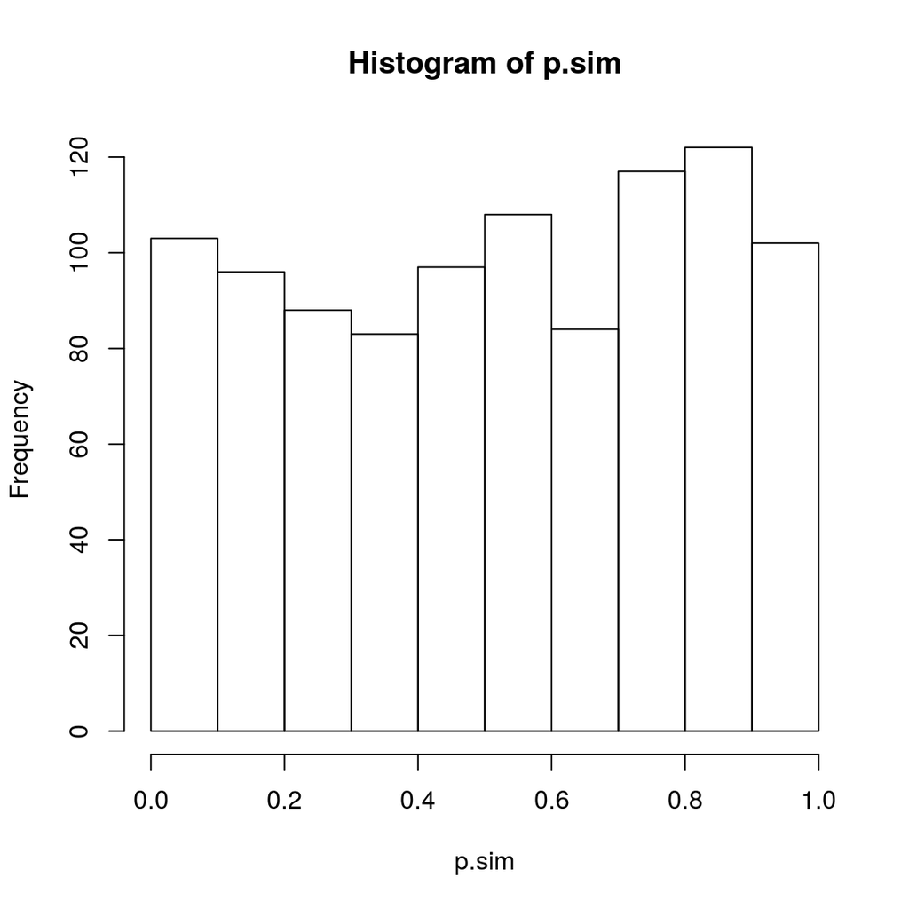

```r
hist(p.sim)
```

```r
#quanti p<.05
sum(p.sim<.05)
```

```
## [1] 56
```

```r
#proporzione
mean(p.sim<.05)
```

```
## [1] 0.056
```

Possiamo quindi guardare le cumulate

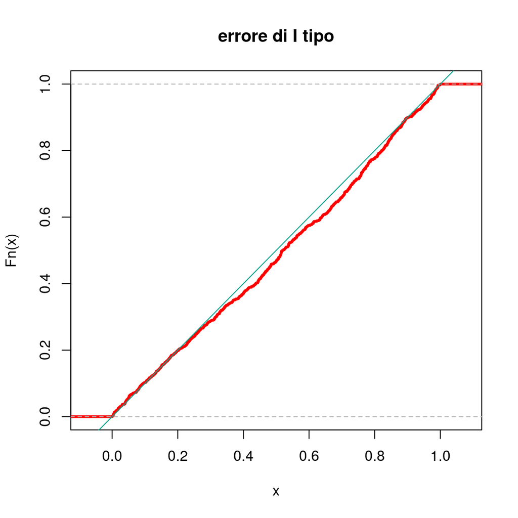

```r
plot(ecdf(p.sim),col=1,main="errore di I tipo",lwd=3)
abline(0,1,col=2)
```

Per ogni valore dell’ascissa $\alpha$ vediamo la stima empirica dell’errore di I tipo. Va molto bene :)

## Sotto $H_1$

C’è relazione tra $n.scarpe$ e $h$. Posso usare errori normali con parametri calcolati sul campione

```r
modelF=lm(h~n.scarpe,data=datiF)
summary(modelF)
```

```
##
## Call:
## lm(formula = h ~ n.scarpe, data = datiF)
##
## Residuals:
##     Min      1Q  Median      3Q     Max
## -8.3407 -2.4409  0.6593  2.4087 10.7596
##
## Coefficients:
##             Estimate Std. Error t value Pr(>|t|)
## (Intercept) 124.5305    17.7856   7.002 2.44e-07 ***
## n.scarpe      1.1003     0.4639   2.372   0.0257 *
## ---
## Signif. codes:  0 '***' 0.001 '**' 0.01 '*' 0.05 '.' 0.1 ' ' 1
##
## Residual standard error: 4.404 on 25 degrees of freedom
## Multiple R-squared:  0.1837, Adjusted R-squared:  0.151
## F-statistic: 5.625 on 1 and 25 DF,  p-value: 0.02571
```

```r
yhat=124.5+1.1*datiF$n.scarpe
s=4.404

#seleziono solo gli n.scarpe delle femmine
n=length(datiF$n.scarpe)
# simulo h
h=rnorm(n,yhat,s)
#e stimo i parametri
summary(lm(h~n.scarpe,data=datiF))
```

```
##
## Call:
## lm(formula = h ~ n.scarpe, data = datiF)
##
## Residuals:
##     Min      1Q  Median      3Q     Max
## -8.3407 -2.4409  0.6593  2.4087 10.7596
##
## Coefficients:
##             Estimate Std. Error t value Pr(>|t|)
## (Intercept) 124.5305    17.7856   7.002 2.44e-07 ***
## n.scarpe      1.1003     0.4639   2.372   0.0257 *
## ---
## Signif. codes:  0 '***' 0.001 '**' 0.01 '*' 0.05 '.' 0.1 ' ' 1
##
## Residual standard error: 4.404 on 25 degrees of freedom
## Multiple R-squared:  0.1837, Adjusted R-squared:  0.151
## F-statistic: 5.625 on 1 and 25 DF,  p-value: 0.02571
```

Ora genero molti (1000?) di questi dataset e conservo il p-value

```r
p.sim=replicate(1000,sim(datiF$n.scarpe,n,yhat,s))
```

- Cosa mi aspetto che siano questi p-value?
- Se faccio un istogramma cosa mi aspetto di vedere?
- Quale sarà la proporzione di p-values$\leq 0.05$?

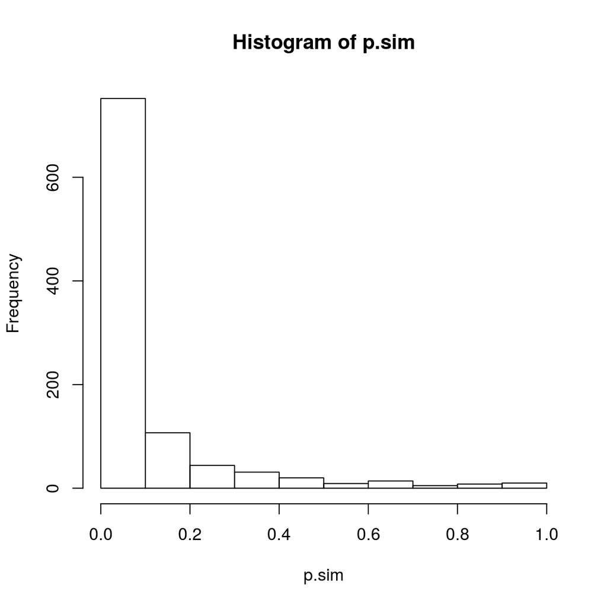

```r
hist(p.sim)
```

```r
#quanti p<.05
sum(p.sim<.05)
```

```
## [1] 633
```

```r
#proporzione
mean(p.sim<.05)
```

```
## [1] 0.633
```

Possiamo quindi guardare le cumulate

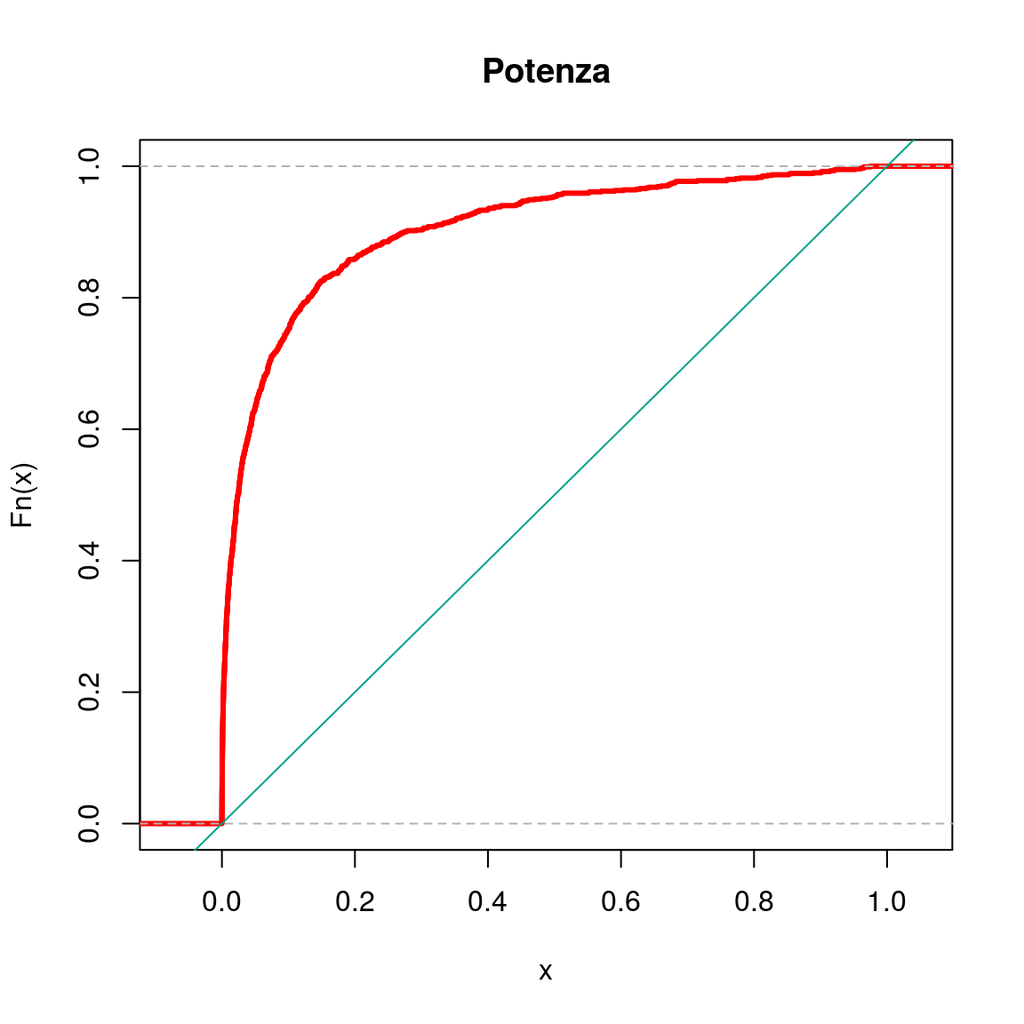

```r
plot(ecdf(p.sim),col=1,main="Potenza",lwd=3)
abline(0,1,col=2)
```

Per ogni valore dell’ascissa $\alpha$ vediamo la stima empirica della potenza.

**Approfondimento:**  
- Come variano gli errori di primo tipo se modifichiamo la deviazione standard degli errori?  
- Come varia se variamo la numerosità del campione?  
- Stesse domande per la simulazione sotto $H_1$ (studio della potenza)  
- Fare valutazioni analoghe per gli intervalli di confidenza